# Proyecto Fin de Máster Data Science, Big Data y Business Analytics

## 6. Descomposición estacional serie histórica IPC

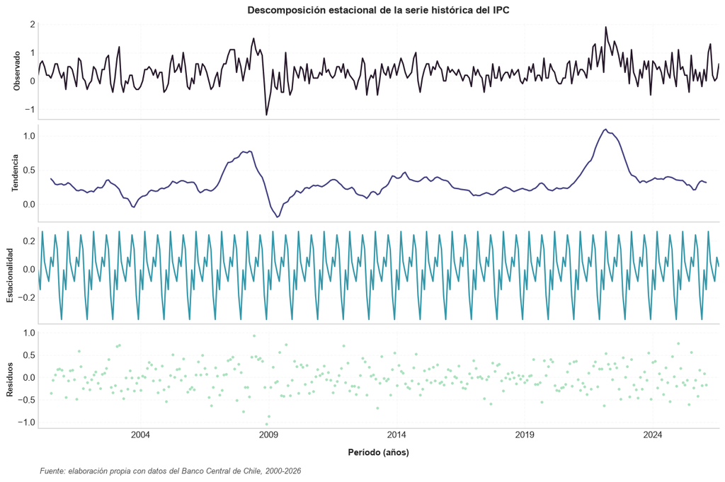

**Figura 7:**  
**Análisis estacional de serie IPC.**  
**1. Serie Original - *Observado***  
Refleja la alta volatilidad de la variación mensual del IPC. Se observan claramente dos shocks relevantes: la crisis financiera de 2008-2009 yel efecto inflacionario de la Pandemia del COVID19 (2021-2023) en Chile.  
**2. Ciclo subyacente - *Tendencia***  
Captura el comportamiento de mediano plazo de la inflación. La tendencia se mantuvo relativamente estable durante gran parte de la década de 2010. No obstante, se observa un repunte estructural desde 2021, probablemente por la crisis sanitaria global, para mostrar cierta convergencia hacia el final de la serie.  
**3. Patrón anual (*m*=12) - *Estacionalidad***  
Se observa un patrón periódico bastante estable, regular y simétrico año tras año. Esto justifica la inclusión de componentes estacionales, tanto el uso de *m*=12 en SARIMA o la inclusión de rezagos estacionales en los modelos de Machine Learning.  
**4. Componente aleatorio - *Residuos***  
Fluctúan de manera estacionaria alrededor de cero. Sin embargo, se observa un incremento en la varianza de los residuos durante los períodos de crisis (2008-2009 y 2021-2022), lo que evidencia que los shocks exógenos imprevisibles elevan temporalmente el error de estimación estructural.

```python
texto_descomp_ipc = ("\n"
f"<b>Análisis estacional de serie IPC.</b> <br><br>"
f"<b>1. Serie Original - <i>Observado</i> </b>"
f"<br>"
f"Refleja la alta volatilidad de la variación mensual del IPC. Se observan claramente dos shocks relevantes: la crisis financiera de 2008-2009 y"
f"el efecto inflacionario de la Pandemia del COVID19 (2021-2023) en Chile. <br><br>"
f"<b>2. Ciclo subyacente - <i>Tendencia</i>  </b>"
f"<br>"
f"Captura el comportamiento de mediano plazo de la inflación. La tendencia se mantuvo relativamente estable durante gran parte de la década de 2010."
f" No obstante, se observa un repunte estructural desde 2021, probablemente por la crisis sanitaria global, para mostrar cierta convergencia"
f" hacia el final de la serie. <br><br>"
f"<b>3. Patrón anual (<i>m</i>=12) - <i>Estacionalidad</i> </b>"
f"<br>"
f"Se observa un patrón periódico bastante estable, regular y simétrico año tras año. Esto justifica la inclusión de componentes estacionales, tanto el"
f" uso de <i>m</i>=12 en SARIMA o la inclusión de rezagos estacionales en los modelos de Machine Learning.<br><br>"
f"<b>4. Componente aleatorio - <i>Residuos</i> </b>"
f"<br>"
f"Fluctúan de manera estacionaria alrededor de cero. Sin embargo, se observa un incremento en la varianza de los residuos durante los períodos de crisis"
f" (2008-2009 y 2021-2022), lo que evidencia que los shocks exógenos imprevisibles elevan temporalmente el error de estimación estructural.<br><br>"
)

graficar_descomposicion_ipc(
    serie_ipc=ts_ipc,
    ancho=130,
    texto_comentario=texto_descomp_ipc,
    nfig="Figura 7",
)
```

## 7. Análisis Autocorrelación (ACF) y Autocorrelación Parcial (PACF) del IPC

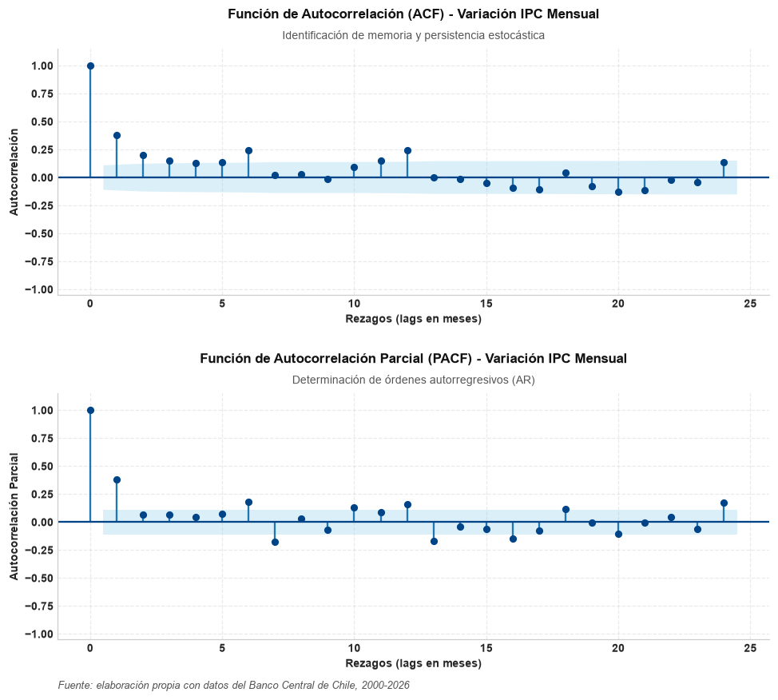

**Figura 8:**  
**Análisis gráfico de funciones de autocorrelación y autocorrelación parcial.**  
**Interpretación gráfica ACF:**  
• Se observa un máximo que sobresale de la banda de confianza en el rezago 1 (~0.40), seguido de un decaimiento acelerado. Además de pequeños repuntes estacionales aislados (rezagos 6 y 12).  
• Se confirma la presencia de inercia inflacionaria de corto plazo (la inflación en *t-1* afecta la inflación en *t*) y se sugiere un componente de media móvil (*q*).  
**Interpretación gráfica PACF:**  
• Se observa un máximo que sobresale de la banda de confianza en el rezago 1 (~0.40) y una caída abrupta, donde los demás rezagos se ubican, casi en su totalidad, dentro de las bandas de confianza.  
• La caída estrepitosa luego del primer rezago es un indicador de un proceso AR de orden 1 (*p* = 1).  
**Comentarios generales:**  
• El corte abrupto tras el primer rezago en PACF y el decaimiento rápido en ACF justifican la elección de un parámetro AR *p*=1 y un parámetro MA *q*=1.  
• Ambos gráficos exhiben repuntes de periodicidad entorno a los rezagos que son múltiplos de 12, validando la incorporación del componente estacional *m*=12.  
• Estructuras estacionales candidatas: dado que los repuntes en torno al rezago 12 se encuentran en los límites de la banda de confianza, la estructura estacional presenta incertidumbre analítica. Esto justifica evaluar tres variantes de competencia mediante el criterio de información de Akaike (AIC). El modelo completo (1,0,1)(1,0,1,12), y opciones sin el término AR(1) o sin MA(1).  
• Esta estacionalidad anual también debe contemplarse en las demás arquitecturas: de proyección: Holt-Winters, Meta-Prophet, LightGBM Direct, Modelos VAR-ML y VAR-TCN.

```python
texto_acf_pacf = ("\n"
"<b>Análisis gráfico de funciones de autocorrelación y autocorrelación parcial.</b> <br><br>"
"<b>Interpretación gráfica ACF:</b>"
"<br>"
"• Se observa un máximo que sobresale de la banda de confianza en el"
" rezago 1 (~0.40), seguido de un decaimiento acelerado. Además de"
" pequeños repuntes estacionales aislados (rezagos 6 y 12).\n"
"• Se confirma la presencia de inercia inflacionaria de corto plazo (la"
" inflación en <i>t-1</i> afecta la inflación en <i>t</i>) y se sugiere un"
" componente de media móvil (<i>q</i>).<br><br>"
"<b>Interpretación gráfica PACF:</b>"
"<br>"
"• Se observa un máximo que sobresale de la banda de confianza en el"
" rezago 1 (~0.40) y una caída abrupta, donde los demás rezagos se ubican,"
" casi en su totalidad, dentro de las bandas de confianza.\n"
"• La caída estrepitosa luego del primer rezago es un indicador de un"
" proceso AR de orden 1 (<i>p</i> = 1).<br><br>"
"<b>Comentarios generales:</b>"
"<br>"
"• El corte abrupto tras el primer rezago en PACF y el decaimiento rápido en ACF"
" justifican la elección de un parámetro AR <i>p</i>=1 y un parámetro MA <i>q</i>=1.\n"
"• Ambos gráficos exhiben repuntes de periodicidad entorno a los rezagos que son"
" múltiplos de 12, validando la incorporación del componente estacional <i>m</i>=12.\n"
"• Estructuras estacionales candidatas: dado que los repuntes en torno al rezago 12 se"
" encuentran en los límites de la banda de confianza, la estructura estacional presenta"
" incertidumbre analítica. Esto justifica evaluar tres variantes de competencia mediante"
" el criterio de información de Akaike (AIC). El modelo completo (1,0,1)(1,0,1,12), y"
" opciones sin el término AR(1) o sin MA(1).\n"
"• Esta estacionalidad anual también debe contemplarse en las demás arquitecturas:"
" de proyección: Holt-Winters, Meta-Prophet, LightGBM Direct, Modelos VAR-ML y VAR-TCN."
)

graficar_acf_pacf(
    serie_ipc=ts_ipc,
    ancho=120,
    texto_comentario=texto_acf_pacf,
    lags=24,
    nfig="Figura 8",
)
```

### Mejor configuración SARIMA - según AIC

```python
candidatos_sarima = [
    {'order': (1, 0, 1), 'seasonal_order': (1, 0, 1, 12)},
    {'order': (1, 0, 1), 'seasonal_order': (1, 0, 0, 12)},
    {'order': (1, 0, 1), 'seasonal_order': (0, 0, 1, 12)}
]

mejor_aic = float('inf')
mejor_config = None

for cfg in candidatos_sarima:
    modelo = SARIMAX(ts_ipc, **cfg, enforce_stationarity=False, enforce_invertibility=False)
    resultado = modelo.fit(disp=False)
    if resultado.aic < mejor_aic:
        mejor_aic = resultado.aic
        mejor_config = cfg

print(f"Mejor configuración según AIC: {mejor_config} con un AIC de {mejor_aic:.2f}")
```

```
Mejor configuración según AIC: {'order': (1, 0, 1), 'seasonal_order': (1, 0, 1, 12)} con un AIC de 251.19
```

# Consideraciones generales

## 1. Determinación dinámica del horizonte (pasos) - según la moneda del contrato

```python
# ==============================================================================
# HORIZONTE DE PROYECCIÓN
# ==============================================================================
if moneda_contrato == "CLP":
  # --- Fecha máxima de término del calendario CLP ---
  f_max_calendario = pd.to_datetime(
      calendario_reajustes["fin_reajuste"].max()
  )

  # --- Diferencia (en meses) entre el último IPC real y el fin del calendario ---
  pasos_dinamicos = (
      (f_max_calendario.year - f_disponible_IPCreal.year) * 12
      + f_max_calendario.month
      - f_disponible_IPCreal.month
  )

  # --- CONTROL: que la proyección sea de - al menos - 1 mes si el cálculo es menor ---
  pasos_dinamicos = max(1, pasos_dinamicos)

elif moneda_contrato == "UF":
  # --- Se asume que para UF, la proyección estándar es de 12 meses SIEMPRE ---
  pasos_dinamicos = 12

# ==============================================================================
# HORIZONTE DE BACKTEST
# ==============================================================================
# ------------------------------------------------------------------------------
# 1. Pasos de Backtest para la mayoría de los modelos
# ------------------------------------------------------------------------------
pasos_backtest = min(pasos_dinamicos, 12)

# ------------------------------------------------------------------------------
# 2. Pasos de Backtest (y proyección) para EEE, pues siempre es un mes vista
# ------------------------------------------------------------------------------
pasos_eee = 1 ## siempre es un mes vista
horizonte_eee = 1 ## siempre revisa 1 mes
```

## 2. Parametrización de fechas de corte para Backtest

```python
# ==============================================================================
# 1. Extracción de calendario y datos de IPC
# ==============================================================================
# ------------------------------------------------------------------------------
# Para la mayoría de los modelos ➔ Desde df_macro_mensual
# ------------------------------------------------------------------------------
fechas_mensuales_general = df_macro_mensual.index
ipc_real_mensual = df_macro_mensual['var_ipc'].astype(float)

# ------------------------------------------------------------------------------
# Para SARIMA                    ➔ Desde ts_ipc (Serie de IPC)
# ------------------------------------------------------------------------------
fechas_mensuales_sarima = ts_ipc.index
ipc_real_mensual_sarima = ts_ipc.astype(float)

# ==============================================================================
# 2. Holgura de - al menos - 12 meses para tener información para el backtest
# ==============================================================================
fin_idx = -pasos_backtest + 1 if pasos_backtest > 1 else None

# ==============================================================================
# 3. Fechas de corte para backtest
# ==============================================================================
fechas_corte_btest_general = fechas_mensuales_general[-(N_TEST + pasos_backtest - 1) : fin_idx]
fechas_corte_btest_sarima = fechas_mensuales_sarima[-(N_TEST + pasos_backtest - 1) : fin_idx]

# ==============================================================================
# 4. Resumen
# ==============================================================================
titulo = f"• Ventanas de backtest a evaluar (N_TEST): {N_TEST} •"
print_marco(titulo, ANCHO_GLOBAL)

df_comp_datos = pd.DataFrame({
    'General': [
        df_macro_mensual.index[0].strftime('%Y-%m'),
        df_macro_mensual.index[-1].strftime('%Y-%m'),
    ],
    'SARIMA': [
        ts_ipc.index[0].strftime('%Y-%m'),
        ts_ipc.index[-1].strftime('%Y-%m'),
    ]
}, index=[
    'Inicio de la serie',
    'Fin de la serie',
])


df_comp_backtest = pd.DataFrame({
    'General': [
        len(fechas_corte_btest_general),
        fechas_corte_btest_general[0].strftime('%Y-%m'),
        fechas_corte_btest_general[-1].strftime('%Y-%m')
    ],
    'SARIMA': [
        len(fechas_corte_btest_sarima),
        fechas_corte_btest_sarima[0].strftime('%Y-%m'),
        fechas_corte_btest_sarima[-1].strftime('%Y-%m')
    ]
}, index=[
    'Total de cortes',
    'Primer corte',
    'Último corte'
])

print(f"• {'Horizonte de predicción (pasos)':<40} : {pasos_backtest}")
print("─" * ANCHO_GLOBAL)
print(f"• {'Datos':<40}")
display(df_comp_datos)

print(f"• {'Backtest':<40}")
display(df_comp_backtest)
print("─" * ANCHO_GLOBAL)
```

```
═══════════════════════════════════════════════════════════════════════════
              • Ventanas de backtest a evaluar (N_TEST): 36 •
═══════════════════════════════════════════════════════════════════════════
• Horizonte de predicción (pasos)          : 12
───────────────────────────────────────────────────────────────────────────
• Datos
```

|  | General | SARIMA |
| --- | --- | --- |
| Inicio de la serie | 2000-01 | 2000-01 |
| Fin de la serie | 2026-09 | 2026-08 |

```
• Backtest
```

|  | General | SARIMA |
| --- | --- | --- |
| Total de cortes | 36 | 36 |
| Primer corte | 2022-11 | 2022-10 |
| Último corte | 2025-10 | 2025-09 |

## 3. DF mensual estacionarizado

```python
df_mensual_estacionario, exito_estacionariedad = verificar_y_estacionarizar(df_macro_mensual)
```

## 4. Check condición de estacionariedad

```python
check_estacionariedad = 'OK' if exito_estacionariedad else 'NO'
```

# Modelamiento

- **Propósito en la app:** Sirve como la "vara de medir" o línea base para evaluar si nuestros modelos de Machine Learning y SARIMA logran batir o no al consenso del mercado.

$$\text{Promedio}(\text{RMSE}_i) \neq \sqrt{\frac{1}{N} \sum (y - \hat{y})^2}$$

Al promediar las raíces (RMSE) se le resta peso a los errores grandes de ciertas ventanas (se suaviza artificialmente la variabilidad) y no corresponde al RMSE global de todo el backtest.

Solución: no guardar el RMSE parcial de cada ventana en la lista errores, sino acumular todos los errores residuales puntuales (o la diferencia y-y techo) de todas las ventanas en uan sola lista global y al final, calcular la raíz cuadrada del error cuadrático medio sobre la combinación de todos esos puntos.

## 3.1 Encuesta de Expectativas Económicas de Inflación (EEE)

Este enfoque no utiliza un algoritmo matemático propio, sino que aprovecha la sabiduría del mercado ($Wisdom of the Crowds$). Toma como referencia la mediana de las proyecciones de la Encuesta de Expectativas Económicas (EEE) del Banco Central de Chile, la cual consulta mensualmente a un grupo selecto de académicos, consultores y ejecutivos del sistema financiero.

**Consolidación y transformación de la serie** Se integra la serie mensual de expectativas como benchmark de mercado:

1. *exp_ipc* (predictor exógeno): mediana de la expectativa de variación del IPC mensual para el mes subsiguiente, extraída de la EEE.
2. *variacion_ipc* (target / realidad): variación efectiva del IPC publicada posteriormente por el Instituto Nacional de Estadísticas (INE).

**Ingeniería de características y arquitectura de evaluación** Se define formalmente el error de pronóstico de las expectativas frente a la realidad observada mediante la siguiente relación:

$$ \text{Error}_{t+1} = \hat{Y}_{t+1}^{\text{EEE}} - Y_{t+1}^{\text{Real}} $$

Donde $\hat{Y}_{t+1}^{\text{EEE}}$ es la expectativa capturada en la encuesta del mes $t$ para el mes $t+1$, y $Y_{t+1}^{\text{Real}}$ es el dato oficial observado.

**Consideraciones**

- Alineamiento temporal: se cruzan las series mediante un `Inner Join` para garantizar que la proyección se evalúe exactamente contra el dato del mes objetivo subsiguiente.
- Normalización de escala: cálculo del error cuadrático sobre tasas porcentuales directas, garantizando homogeneidad de escala con los demás modelos analizados.
- Benchmark de mercado: es una referencia clave para evaluar si los modelos algorítmicos logran superar la información ya incorporada por los agentes económicos.

### 3.1.1. Proyección EEE

```python
# ==============================================================================
# PROYECCIÓN ➔ EEE
# ==============================================================================
fechas_mensuales_eee = df_ipc.resample('MS').last().index
fechas_corte_btest_eee = fechas_mensuales_eee[-(N_TEST + 1) : -1]

df_proyeccion_eee = obtener_proyeccion_eee(df_eee, fecha_corte=f_fecha_corte)
print_proyeccion("Expectativas Mensuales (EEE)", df_proyeccion_eee, pasos_eee, ANCHO_PROY)

texto_proy_eee = ("\n"
    "<b>Proyección EEE.</b>"
    "<br><br>"
    f"• El mes proyectado (<i>t</i>+1) corresponde a {df_proyeccion_eee.index[0].strftime('%Y-%m')}.\n"
    f"• El período evaluado comprende desde {fechas_corte_btest_eee[0].strftime('%Y-%m')} hasta {fechas_corte_btest_eee[-1].strftime('%Y-%m')}.\n"
    "• La proyección del IPC a un mes vista corresponde a 0.40%."
)
print_box_comentario(texto_proy_eee, ANCHO_PROY, "Tabla 2")
print("✓ Benchmark de Mercado guardado exitosamente en 'resultados_proyecciones'.")
```

```
══════════════════════════════════════════════════════════════════════
          • Proyección IPC - Expectativas Mensuales (EEE) •
══════════════════════════════════════════════════════════════════════
• Horizonte proyectado : 1 mes
──────────────────────────────────────────────────────────────────────
```

**Desglose de proyecciones por horizonte (meses)**

|  | IPC Proyectado (%) |
| --- | --- |
| 2026-09-01 | 0.40% |

**Tabla 2:**  
**Proyección EEE.**  
• El mes proyectado (*t*+1) corresponde a 2026-09.  
• El período evaluado comprende desde 2023-08 hasta 2026-07.  
• La proyección del IPC a un mes vista corresponde a 0.40%.

```
✓ Benchmark de Mercado guardado exitosamente en 'resultados_proyecciones'.
```

### 3.1.2. Backtest EEE

```python
# ==============================================================================
# BACKTEST ➔ EEE
# ==============================================================================
residuos_globales_eee, residuos_globales_naive_eee, _ = ejecutar_backtest_eee(
    eee_data=df_eee, df_ipc_real=df_ipc, n_test=N_TEST
)

if len(residuos_globales_eee) > 0:
  if "resultados_backtest" not in globals():
    resultados_backtest = {}
  if "tablas_metricas_backtest" not in globals():
    tablas_metricas_backtest = {}

  # --- Diccionario de residuos por horizonte para h=1 ---
  residuos_por_h_eee = {pasos_eee: residuos_globales_eee}
  residuos_por_h_naive_eee = {pasos_eee: residuos_globales_naive_eee}

  resultados_backtest["EEE"], _ = calcular_metricas_backtest(
      residuos_globales=residuos_globales_eee,
      residuos_por_h=residuos_por_h_eee,
      residuos_naive_globales=residuos_globales_naive_eee,
      residuos_naive_por_h=residuos_por_h_naive_eee,
      pasos_backtest=pasos_eee
  )

  print_backtest(
      nombre_modelo="Expectativas Mensuales (EEE)",
      rmse_global_pct=resultados_backtest["EEE"]["rmse_global_pct"],
      rmse_global_pb=resultados_backtest["EEE"]["rmse_global_pb"],
      mae_global_pct=resultados_backtest["EEE"]["mae_global_pct"],
      mae_global_pb=resultados_backtest["EEE"]["mae_global_pb"],
      me_global_pct=resultados_backtest["EEE"]["me_global_pct"],
      me_global_pb=resultados_backtest["EEE"]["me_global_pb"],
      theil_u_global=resultados_backtest["EEE"]["theil_u_global"],
      n_ventanas=resultados_backtest["EEE"]["ventanas"],
      tabla_metricas=None,
      pasos_backtest=pasos_eee,
      ancho=ANCHO_BTEST,
      nota="validación cruzada recursiva a 1 mes vista (t+1).",
  )

else:
  print("No fue posible calcular las métricas de backtest para EEE.")
```

```
══════════════════════════════════════════════════════════════════════════════════════════════════════════════
                            • RESULTADOS BACKTEST: Expectativas Mensuales (EEE) •
══════════════════════════════════════════════════════════════════════════════════════════════════════════════
• Horizonte evaluado   : 1 mes
• Ventanas evaluadas   : 36
• RMSE global          : 0.3532% (35 pb)
• MAE global           : 0.2639% (26 pb)
• ME global            : 0.0417% (4 pb)
• Theil's U global     : 0.5491
──────────────────────────────────────────────────────────────────────────────────────────────────────────────
Nota: validación cruzada recursiva a 1 mes vista (t+1).
──────────────────────────────────────────────────────────────────────────────────────────────────────────────
```

**Conclusión:** Las proyecciones de inflación mensual del modelo Expectativas Mensuales (EEE), con un backtest de **36 ventanas**, a **1 mes** registran un **RMSE global** de **35 puntos base (0.35%)** y un **MAE global** de **26 puntos base (0.26%)** respecto a la inflación real observada. Adicionalmente, presentan un **sesgo medio** de **4 puntos base (0.04%)**, evidenciando una tendencia sistemática a subestimar los datos reales. Finalmente, se obtuvo un **Coeficiente de Theil (U)** de **0.5491**, lo que demuestra superioridad predictiva frente al benchmark Naïve.

## BASELINE ESTADÍSTICO UNIVARIADO

## 3.2. Modelo de Suavizamiento Exponencial Clásico (Holt-Winters / Exponential Triple Smoothing) [H-W/ETS]

Este enfoque representa el baseline determinista y estadístico clásico por excelencia, diseñado para descomponer la serie temporal en su nivel base, tendencia y estacionalidad mediante ponderaciones exponencialmente decrecientes.

**Consolidación y transformación de la serie**

Se procesa la serie temporal de inflación considerando su alta inercia y dependencia de los ciclos anuales:

1. *var_ipc* (endógena/target): variación mensual del IPC sobre la cual operan las ecuaciones de suavizamiento.

**Ingeniería de características y arquitectura de componentes**

$$ \begin{aligned} \text{Ecuación de Nivel:} &\quad l_t = \alpha(y_t - s_{t-s}) + (1 - \alpha)(l_{t-1} + b_{t-1}) \\ \text{Ecuación de Tendencia:} &\quad b_t = \beta(l_t - l_{t-1}) + (1 - \beta)b_{t-1} \\ \text{Ecuación Estacional:} &\quad s_t = \gamma(y_t - l_{t-1} - b_{t-1}) + (1 - \gamma)s_{t-s} \end{aligned} $$

Donde $\alpha$, $ \beta$ y $\gamma$ corresponden a los parámetros de suavizamiento de nivel, la tendencia y la estacionalidad, respectivamente. Además, se incorpora opcionalmente un factor de amortiguación de tendencia (*damped trend*) para evitar proyecciones divergentes a mediano plazo.

**Consideraciones**

- Benchmark Determinista: sirve como el estándar base de menor complejidad computacional para evaluar si los algoritmos complejos de Machine Learning o Deep Learning aportan ganancias reales de precisión predictiva.
- Optimización Automática: estimación interna de los coeficientes de suavizamiento mediante la maximización de la verosimilitud de la estructura de error (ETS).
- Proyección a Mediano Plazo: generación de pronósticos estables condicionados por la persistencia de los patrones históricos de nivel y estacionalidad.

### 3.2.1. Proyección Holt - Winters

```python
# ==============================================================================
# PROYECCIÓN ➔ HOLT - WINTERS
# ==============================================================================
if 'resultados_proyecciones' not in globals():
    resultados_proyecciones = {}

nombre_modelo = 'Holt-Winters'

resultados_proyecciones[nombre_modelo] = proyectar_holt_winters(
    df_mensual_input=df_macro_mensual,
    pasos=pasos_dinamicos,
    fecha_corte=f_disponible_IPCreal,
    config=CONFIG_HW,
    config_fallback=CONFIG_HW_FB
).to_frame()

print_proyeccion(
    nombre_modelo=nombre_modelo,
    df_proyeccion=resultados_proyecciones[nombre_modelo],
    pasos=pasos_dinamicos,
    ancho=ANCHO_PROY
)

print_analisis_proyeccion(nombre_modelo, resultados_proyecciones, ANCHO_PROY, id_tabla="Tabla 3")
print("✓ Modelo Holt-Winters proyectado y guardado exitosamente en 'resultados_proyecciones'.")
```

```
══════════════════════════════════════════════════════════════════════
                  • Proyección IPC - Holt-Winters •
══════════════════════════════════════════════════════════════════════
• Horizonte proyectado : 12 meses
──────────────────────────────────────────────────────────────────────
```

**Desglose de proyecciones por horizonte (meses)**

|  | IPC Proyectado (%) |
| --- | --- |
| 2026-09-01 | 0.61% |
| 2026-10-01 | 0.51% |
| 2026-11-01 | 0.18% |
| 2026-12-01 | 0.01% |
| 2027-01-01 | 0.35% |
| 2027-02-01 | 0.24% |
| 2027-03-01 | 0.65% |
| 2027-04-01 | 0.46% |
| 2027-05-01 | 0.33% |
| 2027-06-01 | 0.27% |
| 2027-07-01 | 0.44% |
| 2027-08-01 | 0.39% |

**Tabla 3:**  
**Proyección Holt-Winters.**  
• Se registra **una trayectoria general a la baja (descendiendo desde 0.61% en 2026-09 hasta 0.39% en 2027-08)** a lo largo del horizonte evaluado de 12 meses.  
• Las principales variaciones se ubican en un máximo de **0.65%** (2027-03) y un mínimo de **0.01%** (2026-12), exhibiendo alta volatilidad estacional (desviación estándar de 0.18 pp).  
• La **variación mensual esperada**, en promedio, para el periodo de pronóstico es de **0.37%**.

```
✓ Modelo Holt-Winters proyectado y guardado exitosamente en 'resultados_proyecciones'.
```

### 3.2.2. Backtest Holt - Winters

```python
# ==============================================================================
# BACKTEST ➔ HOLT-WINTERS
# ==============================================================================
residuos_globales_hw, residuos_por_h_hw, residuos_globales_naive_hw, residuos_por_h_naive_hw, ventanas_evaluadas_hw = ejecutar_backtest_holt_winters(
    df_mensual_input=df_macro_mensual,
    ipc_real_mensual=ipc_real_mensual,
    fechas_corte_btest=fechas_corte_btest_general,
    pasos_backtest=pasos_backtest,
    config=CONFIG_HW,
    config_fallback=CONFIG_HW_FB
)

nombre_modelo = "Holt-Winters"
if len(residuos_globales_hw) > 0:
    if 'resultados_backtest' not in globals():
        resultados_backtest = {}
    if 'tablas_metricas_backtest' not in globals():
        tablas_metricas_backtest = {}

    resultados_backtest[nombre_modelo], tablas_metricas_backtest[nombre_modelo] = (calcular_metricas_backtest(
        residuos_globales=residuos_globales_hw,
        residuos_por_h=residuos_por_h_hw,
        residuos_naive_globales=residuos_globales_naive_hw,
        residuos_naive_por_h=residuos_por_h_naive_hw,
        pasos_backtest=pasos_backtest
    ))

    print_backtest(
        nombre_modelo=nombre_modelo,
        rmse_global_pct=resultados_backtest[nombre_modelo]["rmse_global_pct"],
        rmse_global_pb=resultados_backtest[nombre_modelo]["rmse_global_pb"],
        mae_global_pct=resultados_backtest[nombre_modelo]["mae_global_pct"],
        mae_global_pb=resultados_backtest[nombre_modelo]["mae_global_pb"],
        me_global_pct=resultados_backtest[nombre_modelo]["me_global_pct"],
        me_global_pb=resultados_backtest[nombre_modelo]["me_global_pb"],
        theil_u_global=resultados_backtest[nombre_modelo]["theil_u_global"],
        n_ventanas=resultados_backtest[nombre_modelo]["ventanas"],
        tabla_metricas=tablas_metricas_backtest[nombre_modelo],
        pasos_backtest=pasos_backtest,
        ancho=ANCHO_BTEST,
        nota="validación cruzada recursiva (H-W) y estacionalidad anual."
    )

else:
  print("No fue posible calcular las métricas de backtest para Holt-Winters.")
```

```
══════════════════════════════════════════════════════════════════════════════════════════════════════════════
                                    • RESULTADOS BACKTEST: Holt-Winters •
══════════════════════════════════════════════════════════════════════════════════════════════════════════════
• Horizonte evaluado   : 12 meses
• Ventanas evaluadas   : 35
• RMSE global          : 0.4284% (43 pb)
• MAE global           : 0.3463% (35 pb)
• ME global            : -0.0715% (-7 pb)
• Theil's U global     : 0.6590
──────────────────────────────────────────────────────────────────────────────────────────────────────────────
```

**Desglose de métricas de error por horizontes de proyección (meses)**

|  | RMSE Global (%) | RMSE Global (pb) | MAE Global (%) | MAE Global (pb) | ME Global (%) | ME Global (pb) | Theil's U |
| --- | --- | --- | --- | --- | --- | --- | --- |
| 1 | 0.4264 | 43 | 0.3546 | 35 | -0.0735 | -7 | 0.6346 |
| 2 | 0.4008 | 40 | 0.3342 | 33 | -0.0772 | -8 | 0.6042 |
| 3 | 0.4250 | 43 | 0.3406 | 34 | -0.0981 | -10 | 0.6407 |
| 4 | 0.4344 | 43 | 0.3569 | 36 | -0.0869 | -9 | 0.6646 |
| 5 | 0.4545 | 45 | 0.3715 | 37 | -0.1071 | -11 | 0.7272 |
| 6 | 0.4284 | 43 | 0.3549 | 35 | -0.0928 | -9 | 0.6766 |
| 7 | 0.4985 | 50 | 0.4107 | 41 | -0.0603 | -6 | 0.7859 |
| 8 | 0.4305 | 43 | 0.3426 | 34 | -0.0486 | -5 | 0.6533 |
| 9 | 0.4240 | 42 | 0.3437 | 34 | -0.0557 | -6 | 0.6503 |
| 10 | 0.4209 | 42 | 0.3314 | 33 | -0.0565 | -6 | 0.6473 |
| 11 | 0.4035 | 40 | 0.3251 | 33 | -0.0521 | -5 | 0.6228 |
| 12 | 0.3832 | 38 | 0.2900 | 29 | -0.0490 | -5 | 0.5933 |

```
──────────────────────────────────────────────────────────────────────────────────────────────────────────────
Nota: validación cruzada recursiva (H-W) y estacionalidad anual.
──────────────────────────────────────────────────────────────────────────────────────────────────────────────
```

**Conclusión:** Las proyecciones de inflación mensual del modelo Holt-Winters, con un backtest de **35 ventanas**, a **12 meses** registran un **RMSE global** de **43 puntos base (0.43%)** y un **MAE global** de **35 puntos base (0.35%)** respecto a la inflación real observada. Adicionalmente, presentan un **sesgo medio** de **-7 puntos base (-0.07%)**, evidenciando una tendencia sistemática a sobreestimar los datos reales. Finalmente, se obtuvo un **Coeficiente de Theil (U)** de **0.6590**, lo que demuestra superioridad predictiva frente al benchmark Naïve.

## 3.3. SARIMA: Seasonal Autoregressive Integrated Moving Average

Este enfoque implementa un modelo econométrico clásico univariado para la predicción de series temporales, diseñado específicamente para capturar tanto la dinámica de autocorrelación interna como los patrones estacionales recurrentes (tales como los ciclos inflacionarios anuales).

**Consolidación y transformación de la serie** Se utiliza la serie temporal univariada en frecuencia mensual (MS) orientada exclusivamente a la endógena:

1. *variacion_ipc* (target): variación mensual del Índice de Precios al Consumidor sujeta a los operadores de diferenciación y rezago.

**Ingeniería de características y arquitectura estocástica**

El modelo se define bajo la notación general $\text{ARIMA}{(p, d, q)} \times {(P, D, Q)_m}$, estructurada en dos partes complementarias: $$ \Phi_p(B)\tilde{\Phi}_P(B^m)(1 - B)^d(1 - B^m)^D y_t = \theta_q(B)\tilde{\theta}_Q(B^m)\varepsilon_t $$

Donde B es el operador de rezago, $(1 - B)^d$ representa la diferenciación regular para eliminar la tendencia, $(1 - B^m)^D$ modela la diferenciación estacional de período $m=12$, y los polinomios $\Phi$ y $\theta$ capturan la estructura autorregresiva y de media móvil tanto en su componente regular ($p,q$) como estacional ($P,Q$)

Para comprender los componentes que alimentan esta especificación:

- AR (autorregesivo ➔ $p$ y $P$); explica el valor actual de la variable en función de sus propios valores pasados (rezagos o lags), capturando la inercia inflacionaria.
- I (integración ➔ $d$ y $D$): aplica procesos de diferenciación para transformar la serie y hacerla estacionaria (estabilizando media y varianza), requisito indispensable para evitar inferencias espurias.
- MA (media móvil ➔ $q$ y $Q$): utiliza los errores de pronóstico pasados (desvíos del modelo) para corregir la predicción actual.
- S (estacional ➔ $m$): modela fluctuaciones que ocurren en intervalos de tiempo fijos ($m=12$ para datos mensuales con ciclo anual y $m=4$ para datos trimestrales) para capturar la estacionalidad anual de los precios).

**Consideraciones**

- Modelación Univariada: proyecta la inflación exclusivamente a partir de su propio historial, sirviendo como el baseline econométrico de referencia.
- Requisito de estacionariedad: requiere el cumplimiento estricto de estacionaridad en media y varianza mediante las operaciones de diferenciación ($d,D$) para asegurar la validez de la inferencia estadística.
- Prevención de data leakage: estimación de coeficientes y pronósticos recursivos condicionados estrictamente al último período de corte histórico (*f_disponible_IPCreal*).

### Justificación del modelo

El modelo se define de la siguiente forma: $$ \text{ARIMA}{(1, 0, 1)} \times {(1, 0, 1)_{12}} $$

- El componente no estacional - $\text{order}(1,0,1)$ permite capturar la inercia de corto plazo:
1. $p=1$ modela la persistencia autorregresiva de corto plazo (el efecto del mes inmediatamente anterior).
2. $d=0$ indica que la serie de variación del IPC ya es estacionaria (ADF p-value 0.0034).
3. $q=1$ incorpora la media móvil para absorber shocks transitorios de ruido blanco.
- El componente estacional - $\text{seasonal\_order}(1,0,1,12)$ modela la persistencia anual de la inflación:
1. $P=1$ y $Q=1$ modelan la memoria estacional a 12 meses.
2. $D=0$ evita diferenciar anualmente una serie que ya pasó el filtro de estacionariedad.
3. $m=12$ para que el modelo capture que la temporalidad y los patrones cíclicos se repiten anualmente.
- Parametrizar *enforce_stationarity* y *enforce_invertibility* como "False" desactiva las restricciones rígidas de estacionariedad e invertibilidad en el espacio de los parámetros durante las iteraciones de optimización de la función de verosimilitud (MLE). Esto evita que el backtest se caiga o arroje errores sustanciales cuando una venetana móvil particular fuerza temporalmente a los coeficientes a los bordes de la región de estacionariedad.

### 3.3.1. Proyección SARIMA

```python
es_estacionaria = evaluar_estacionariedad_serie(ts_ipc, nombre_serie="Variación IPC", ancho=ANCHO_GLOBAL)
```

```
═══════════════════════════════════════════════════════════════════════════
              • TEST DE ESTACIONARIEDAD ADF (VARIACIÓN IPC) •
═══════════════════════════════════════════════════════════════════════════
• P-value    ➔ 0.0033
• Conclusión ➔ La serie es estacionaria (rechazamos raíz unitaria).
═══════════════════════════════════════════════════════════════════════════
```

```python
# ==============================================================================
# PROYECCIÓN ➔ SARIMA
# ==============================================================================
nombre_modelo = 'SARIMA'
if es_estacionaria:
    if 'resultados_proyecciones' not in globals():
        resultados_proyecciones = {}

    resultados_proyecciones[nombre_modelo] = proyectar_sarimax(
        ts_ipc_data=ts_ipc,
        pasos=pasos_dinamicos,
        fecha_corte=f_disponible_IPCreal,
        config=CONFIG_SARIMA
    ).to_frame()

    print_proyeccion(
        nombre_modelo=nombre_modelo,
        df_proyeccion=resultados_proyecciones[nombre_modelo],
        pasos=pasos_dinamicos,
        ancho=ANCHO_PROY,
        nota=f"modelo estimado con ordenes {CONFIG_SARIMA['order']}x{CONFIG_SARIMA['seasonal_order']}"
    )
    print_analisis_proyeccion(nombre_modelo, resultados_proyecciones, ANCHO_GLOBAL, id_tabla="Tabla 4")
    print("✓ Modelo SARIMA proyectado y guardado exitosamente en 'resultados_proyecciones'.")
else:
    print(f"Verifique que la serie sea estacionaria antes de ejecutar el modelo '{nombre_modelo}'.")
```

```
══════════════════════════════════════════════════════════════════════
                     • Proyección IPC - SARIMA •
══════════════════════════════════════════════════════════════════════
• Horizonte proyectado : 12 meses
──────────────────────────────────────────────────────────────────────
```

**Desglose de proyecciones por horizonte (meses)**

|  | IPC Proyectado (%) |
| --- | --- |
| 2026-09-01 | 0.47% |
| 2026-10-01 | 0.49% |
| 2026-11-01 | 0.31% |
| 2026-12-01 | 0.03% |
| 2027-01-01 | 0.54% |
| 2027-02-01 | 0.20% |
| 2027-03-01 | 0.60% |
| 2027-04-01 | 0.47% |
| 2027-05-01 | 0.25% |
| 2027-06-01 | 0.02% |
| 2027-07-01 | 0.42% |
| 2027-08-01 | 0.28% |

```
──────────────────────────────────────────────────────────────────────
Nota: modelo estimado con ordenes (1, 0, 1)x(1, 0, 1, 12)
──────────────────────────────────────────────────────────────────────
```

**Tabla 4:**  
**Proyección SARIMA.**  
• Se registra **una trayectoria general a la baja (descendiendo desde 0.47% en 2026-09 hasta 0.28% en 2027-08)** a lo largo del horizonte evaluado de 12 meses.  
• Las principales variaciones se ubican en un máximo de **0.60%** (2027-03) y un mínimo de **0.02%** (2027-06), exhibiendo alta volatilidad estacional (desviación estándar de 0.19 pp).  
• La **variación mensual esperada**, en promedio, para el periodo de pronóstico es de **0.34%**.

```
✓ Modelo SARIMA proyectado y guardado exitosamente en 'resultados_proyecciones'.
```

### 3.3.2. Backtest SARIMA

```python
# ==============================================================================
# BACKTEST ➔ SARIMA
# ==============================================================================
residuos_globales_sarima, residuos_por_h_sarima, residuos_globales_naive_sarima, residuos_por_h_naive_sarima, ventanas_evaluadas_sarima = ejecutar_backtest_sarima(
    ts_ipc_data=ts_ipc,
    ipc_real_sarima=ipc_real_mensual,
    fechas_corte_btest=fechas_corte_btest_sarima,
    pasos_backtest=pasos_backtest,
    config=CONFIG_SARIMA
)

nombre_modelo = "SARIMA"
if len(residuos_globales_sarima) > 0:
    if 'resultados_backtest' not in globals():
        resultados_backtest = {}
    if 'tablas_metricas_backtest' not in globals():
        tablas_metricas_backtest = {}

    resultados_backtest[nombre_modelo], tablas_metricas_backtest[nombre_modelo] = (calcular_metricas_backtest(
        residuos_globales=residuos_globales_sarima,
        residuos_por_h=residuos_por_h_sarima,
        residuos_naive_globales=residuos_globales_naive_sarima,
        residuos_naive_por_h=residuos_por_h_naive_sarima,
        pasos_backtest=pasos_backtest
    ))

    print_backtest(
        nombre_modelo=nombre_modelo,
        rmse_global_pct=resultados_backtest[nombre_modelo]["rmse_global_pct"],
        rmse_global_pb=resultados_backtest[nombre_modelo]["rmse_global_pb"],
        mae_global_pct=resultados_backtest[nombre_modelo]["mae_global_pct"],
        mae_global_pb=resultados_backtest[nombre_modelo]["mae_global_pb"],
        me_global_pct=resultados_backtest[nombre_modelo]["me_global_pct"],
        me_global_pb=resultados_backtest[nombre_modelo]["me_global_pb"],
        theil_u_global=resultados_backtest[nombre_modelo]["theil_u_global"],
        n_ventanas=resultados_backtest[nombre_modelo]["ventanas"],
        tabla_metricas=tablas_metricas_backtest[nombre_modelo],
        pasos_backtest=pasos_backtest,
        ancho=ANCHO_BTEST,
        nota=f"modelo estimado con ordenes {CONFIG_SARIMA['order']}x{CONFIG_SARIMA['seasonal_order']}"
    )
else:
    print("No fue posible calcular las métricas de backtest para SARIMA.")
```

```
══════════════════════════════════════════════════════════════════════════════════════════════════════════════
                                       • RESULTADOS BACKTEST: SARIMA •
══════════════════════════════════════════════════════════════════════════════════════════════════════════════
• Horizonte evaluado   : 12 meses
• Ventanas evaluadas   : 36
• RMSE global          : 0.3553% (36 pb)
• MAE global           : 0.2842% (28 pb)
• ME global            : 0.0115% (1 pb)
• Theil's U global     : 0.5468
──────────────────────────────────────────────────────────────────────────────────────────────────────────────
```

**Desglose de métricas de error por horizontes de proyección (meses)**

|  | RMSE Global (%) | RMSE Global (pb) | MAE Global (%) | MAE Global (pb) | ME Global (%) | ME Global (pb) | Theil's U |
| --- | --- | --- | --- | --- | --- | --- | --- |
| 1 | 0.4063 | 41 | 0.3450 | 34 | -0.0011 | 0 | 0.6085 |
| 2 | 0.3340 | 33 | 0.2679 | 27 | -0.0145 | -1 | 0.5027 |
| 3 | 0.3435 | 34 | 0.2846 | 28 | -0.0159 | -2 | 0.5211 |
| 4 | 0.3331 | 33 | 0.2758 | 28 | -0.0238 | -2 | 0.5034 |
| 5 | 0.3366 | 34 | 0.2767 | 28 | -0.0160 | -2 | 0.5195 |
| 6 | 0.3189 | 32 | 0.2607 | 26 | -0.0152 | -2 | 0.4995 |
| 7 | 0.3773 | 38 | 0.3007 | 30 | 0.0189 | 2 | 0.6025 |
| 8 | 0.3608 | 36 | 0.2797 | 28 | 0.0270 | 3 | 0.5537 |
| 9 | 0.3570 | 36 | 0.2716 | 27 | 0.0412 | 4 | 0.5488 |
| 10 | 0.3628 | 36 | 0.2794 | 28 | 0.0335 | 3 | 0.5641 |
| 11 | 0.3632 | 36 | 0.2838 | 28 | 0.0524 | 5 | 0.5617 |
| 12 | 0.3616 | 36 | 0.2840 | 28 | 0.0509 | 5 | 0.5661 |

```
──────────────────────────────────────────────────────────────────────────────────────────────────────────────
Nota: modelo estimado con ordenes (1, 0, 1)x(1, 0, 1, 12)
──────────────────────────────────────────────────────────────────────────────────────────────────────────────
```

**Conclusión:** Las proyecciones de inflación mensual del modelo SARIMA, con un backtest de **36 ventanas**, a **12 meses** registran un **RMSE global** de **36 puntos base (0.36%)** y un **MAE global** de **28 puntos base (0.28%)** respecto a la inflación real observada. Adicionalmente, presentan un **sesgo medio** de **1 puntos base (0.01%)**, evidenciando una tendencia sistemática a subestimar los datos reales. Finalmente, se obtuvo un **Coeficiente de Theil (U)** de **0.5468**, lo que demuestra superioridad predictiva frente al benchmark Naïve.

## 3.4. Modelos lineales penalizados (Ridge, Lasso y Elastic Net)

Este enfoque implementa regresiones lineales penalizadas con características rezagadas, sirviendo como un puente robusto entre la econometría tradicional y el aprendizaje automático, mitigando eficazmente la alta multicolinealidad entre las variables financieras fuertemente correlacionadas (UF, TPM y tipo de cambio).

**Consolidación y transformación del dataset multivariado**

Se construyen matrices de características estructuradas a partir de rezagos explícitos para capturar la inercia y los mecanismos de transmisión macroeconómica:

1. *ipc_lags* (endógenas rezagadas): desfases temporales de la inflación para modelar la persistencia e inercia de los precios.
2. *tpm_lags* (exógenas de política): rezagos de la Tasa de Política Monetaria que recogen el retardo temporal de la transmisión monetaria.
3. *usd_std_lags* y *usd_rango_lags* (volatilidad cambiaria): indicadores de dispersión y amplitud del tipo de cambio para capturar la incertidumbre externa.

**Ingeniería de características y arquitectura de penalización**

$$ \min_{\beta} \frac{1}{2n} \|\mathbf{y} - \mathbf{X}\beta\|_2^2 + \alpha \left( \rho \|\beta\|_1 + \frac{1-\rho}{2} \|\beta\|_2^2 \right) $$

Donde la penalización combinada de Ridge ($\ell_2$), Lasso ($\ell_1$) y Elastic Net controla la magnitud de los coeficientes, permitiendo realizar selección automática de variables y estabilizar las estimacioens ante multicolinealidad severa en la matriz $\mathbf{X}$

**Consideraciones**

- Optimización Automatizada de Hiperparámetros: uso de validación cruzada integrada (RidgeCV, LassoCV, ElasticNetCV) para seleccionar la penalización óptima α y la razón de mezcla ρ sin quemar etapas de validación manual.
- Control de Multicolinealidad: reducción de la varianza en los coeficientes estimados ante el fuerte co-movimiento de indicadores financieros e inflacionarios.
- Estrategia de Proyección: despliegue mediante esquemas de regresión directa o recursiva, asegurando consistencia matemática frente a las tendencias de mediano plazo.

### 3.4.1. Proyección Lineal Penalizada

```python
# ==============================================================================
# PROYECCIÓN ➔ MODELOS LINEALES PENALIZADOS
# ==============================================================================
if check_estacionariedad == 'OK':
    if 'resultados_proyecciones' not in globals():
        resultados_proyecciones = {}

    for nombre_modelo, (tipo_algoritmo, cfg) in modelos_lineales_test.items():
        resultados_proyecciones[nombre_modelo] = proyectar_modelo_lineal_penalizado(
            df_mensual_input=df_mensual_estacionario,
            pasos=pasos_dinamicos,
            fecha_corte=f_disponible_IPCreal,
            tipo_lineal=tipo_algoritmo,
            config=cfg
        ).to_frame()
else:
    print("Al menos una serie no es estacionaria. Se omite la proyección de los modelos lineales.")
```

#### 3.4.1.1. Ridge Regression

```python
# --- RIDGE REGRESSION ---
nombre_modelo = "Ridge Regression"

if 'resultados_proyecciones' in globals() and nombre_modelo in resultados_proyecciones:
    print_proyeccion(
        nombre_modelo=nombre_modelo,
        df_proyeccion=resultados_proyecciones[nombre_modelo],
        pasos=pasos_dinamicos,
        ancho=ANCHO_PROY
    )
    print_analisis_proyeccion(nombre_modelo, resultados_proyecciones, ANCHO_GLOBAL, id_tabla="Tabla 5")
    print("✓ Modelo Ridge Regression proyectado y guardado exitosamente en 'resultados_proyecciones'.")
else:
    print(f"No hay proyecciones disponibles para '{nombre_modelo}' (verifique la estacionariedad de las series).")
```

```
══════════════════════════════════════════════════════════════════════
                • Proyección IPC - Ridge Regression •
══════════════════════════════════════════════════════════════════════
• Horizonte proyectado : 12 meses
──────────────────────────────────────────────────────────────────────
```

**Desglose de proyecciones por horizonte (meses)**

|  | IPC Proyectado (%) |
| --- | --- |
| 2026-09-01 | 0.23% |
| 2026-10-01 | 0.19% |
| 2026-11-01 | 0.20% |
| 2026-12-01 | 0.28% |
| 2027-01-01 | 0.35% |
| 2027-02-01 | 0.30% |
| 2027-03-01 | 0.27% |
| 2027-04-01 | 0.22% |
| 2027-05-01 | 0.23% |
| 2027-06-01 | 0.25% |
| 2027-07-01 | 0.34% |
| 2027-08-01 | 0.30% |

**Tabla 5:**  
**Proyección Ridge Regression.**  
• Se registra **una trayectoria general al alza (ascendiendo desde 0.23% en 2026-09 hasta 0.30% en 2027-08)** a lo largo del horizonte evaluado de 12 meses.  
• Las principales variaciones se ubican en un máximo de **0.35%** (2027-01) y un mínimo de **0.19%** (2026-10), exhibiendo baja dispersión y alta estabilidad (desviación estándar de 0.05 pp).  
• La **variación mensual esperada**, en promedio, para el periodo de pronóstico es de **0.26%**.

```
✓ Modelo Ridge Regression proyectado y guardado exitosamente en 'resultados_proyecciones'.
```

#### 3.4.1.2. Lasso Regression

```python
# --- LASSO REGRESSION ---
nombre_modelo = "Lasso Regression"

if 'resultados_proyecciones' in globals() and nombre_modelo in resultados_proyecciones:
    print_proyeccion(
        nombre_modelo=nombre_modelo,
        df_proyeccion=resultados_proyecciones[nombre_modelo],
        pasos=pasos_dinamicos,
        ancho=ANCHO_PROY
    )
    print_analisis_proyeccion(nombre_modelo, resultados_proyecciones, ANCHO_GLOBAL, id_tabla="Tabla 6")
    print("✓ Modelo Lasso Regression proyectado y guardado exitosamente en 'resultados_proyecciones'.")
else:
    print(f"No hay proyecciones disponibles para '{nombre_modelo}' (verifique la estacionariedad de las series).")
```

```
══════════════════════════════════════════════════════════════════════
                • Proyección IPC - Lasso Regression •
══════════════════════════════════════════════════════════════════════
• Horizonte proyectado : 12 meses
──────────────────────────────────────────────────────────────────────
```

**Desglose de proyecciones por horizonte (meses)**

|  | IPC Proyectado (%) |
| --- | --- |
| 2026-09-01 | 0.31% |
| 2026-10-01 | 0.31% |
| 2026-11-01 | 0.31% |
| 2026-12-01 | 0.30% |
| 2027-01-01 | 0.31% |
| 2027-02-01 | 0.31% |
| 2027-03-01 | 0.31% |
| 2027-04-01 | 0.31% |
| 2027-05-01 | 0.28% |
| 2027-06-01 | 0.24% |
| 2027-07-01 | 0.29% |
| 2027-08-01 | 0.31% |

```
✓ Modelo Lasso Regression proyectado y guardado exitosamente en 'resultados_proyecciones'.
```

#### 3.4.1.3. Elastic Net

```python
# --- ELASTIC NET ---
nombre_modelo = "Elastic Net"

if 'resultados_proyecciones' in globals() and nombre_modelo in resultados_proyecciones:
    print_proyeccion(
        nombre_modelo=nombre_modelo,
        df_proyeccion=resultados_proyecciones[nombre_modelo],
        pasos=pasos_dinamicos,
         ancho=ANCHO_PROY
    )
    print_analisis_proyeccion(nombre_modelo, resultados_proyecciones, ANCHO_GLOBAL, id_tabla="Tabla 7")
    print("✓ Modelo Elastic Net proyectado y guardado exitosamente en 'resultados_proyecciones'.")
else:
    print(f"No hay proyecciones disponibles para '{nombre_modelo}' (verifique la estacionariedad de las series).")
```

```
══════════════════════════════════════════════════════════════════════
                   • Proyección IPC - Elastic Net •
══════════════════════════════════════════════════════════════════════
• Horizonte proyectado : 12 meses
──────────────────────────────────────────────────────────────────────
```

**Desglose de proyecciones por horizonte (meses)**

|  | IPC Proyectado (%) |
| --- | --- |
| 2026-09-01 | 0.31% |
| 2026-10-01 | 0.31% |
| 2026-11-01 | 0.31% |
| 2026-12-01 | 0.30% |
| 2027-01-01 | 0.31% |
| 2027-02-01 | 0.31% |
| 2027-03-01 | 0.31% |
| 2027-04-01 | 0.31% |
| 2027-05-01 | 0.28% |
| 2027-06-01 | 0.23% |
| 2027-07-01 | 0.29% |
| 2027-08-01 | 0.31% |

```
✓ Modelo Elastic Net proyectado y guardado exitosamente en 'resultados_proyecciones'.
```

### 3.4.2. Backtest Proyección Lineal Penalizada

```python
# ==============================================================================
# BACKTEST ➔ MODELOS LINEALES PENALIZADOS
# ==============================================================================
if check_estacionariedad == 'OK':
  if 'resultados_backtest' not in globals():
    resultados_backtest = {}
  if 'tablas_metricas_backtest' not in globals():
    tablas_metricas_backtest = {}

  for nombre_modelo, (tipo_algoritmo, cfg) in modelos_lineales_test.items():

    res_glob_lin, res_h_lin, res_glob_naive_lin, res_h_naive_lin, n_vent_lin = ejecutar_backtest_modelo_lineal(
        df_mensual_input=df_mensual_estacionario,
        ipc_real_mensual=ipc_real_mensual,
        fechas_corte_btest=fechas_corte_btest_general,
        pasos_backtest=pasos_backtest,
        tipo_lineal=tipo_algoritmo,
        config=cfg,
    )

    if len(res_glob_lin) > 0:
      resultados_backtest[nombre_modelo], tablas_metricas_backtest[nombre_modelo] = (
          calcular_metricas_backtest(
              residuos_globales=res_glob_lin,
              residuos_por_h=res_h_lin,
              residuos_naive_globales=res_glob_naive_lin,
              residuos_naive_por_h=res_h_naive_lin,
              pasos_backtest=pasos_backtest
          )
      )
    else:
      print(
          f'No fue posible calcular las métricas de backtest para {nombre_modelo}.'
      )
else:
  print(
      'Al menos una serie no es estacionaria. Se omite el backtest de los modelos lineales.'
  )
```

#### 3.4.2.1. Backtest Ridge Regression

```python
# --- RIDGE REGRESSION ---
nombre_modelo = "Ridge Regression"
if 'resultados_backtest' in globals() and nombre_modelo in resultados_backtest:
    print_backtest(
        nombre_modelo=nombre_modelo,
        rmse_global_pct=resultados_backtest[nombre_modelo]['rmse_global_pct'],
        rmse_global_pb=resultados_backtest[nombre_modelo]['rmse_global_pb'],
        mae_global_pct=resultados_backtest[nombre_modelo]["mae_global_pct"],
        mae_global_pb=resultados_backtest[nombre_modelo]["mae_global_pb"],
        me_global_pct=resultados_backtest[nombre_modelo]['me_global_pct'],
        me_global_pb=resultados_backtest[nombre_modelo]['me_global_pb'],
        theil_u_global=resultados_backtest[nombre_modelo]['theil_u_global'],
        n_ventanas=resultados_backtest[nombre_modelo]['ventanas'],
        tabla_metricas=tablas_metricas_backtest[nombre_modelo],
        pasos_backtest=pasos_backtest,
        ancho=ANCHO_BTEST
    )
```

```
══════════════════════════════════════════════════════════════════════════════════════════════════════════════
                                  • RESULTADOS BACKTEST: Ridge Regression •
══════════════════════════════════════════════════════════════════════════════════════════════════════════════
• Horizonte evaluado   : 12 meses
• Ventanas evaluadas   : 35
• RMSE global          : 0.4156% (42 pb)
• MAE global           : 0.3320% (33 pb)
• ME global            : 0.0467% (5 pb)
• Theil's U global     : 0.6393
──────────────────────────────────────────────────────────────────────────────────────────────────────────────
```

**Desglose de métricas de error por horizontes de proyección (meses)**

|  | RMSE Global (%) | RMSE Global (pb) | MAE Global (%) | MAE Global (pb) | ME Global (%) | ME Global (pb) | Theil's U |
| --- | --- | --- | --- | --- | --- | --- | --- |
| 1 | 0.4229 | 42 | 0.3471 | 35 | -0.0098 | -1 | 0.6294 |
| 2 | 0.4200 | 42 | 0.3488 | 35 | 0.0147 | 1 | 0.6331 |
| 3 | 0.4183 | 42 | 0.3391 | 34 | -0.0130 | -1 | 0.6306 |
| 4 | 0.3800 | 38 | 0.3067 | 31 | 0.0456 | 5 | 0.5814 |
| 5 | 0.3320 | 33 | 0.2767 | 28 | 0.0123 | 1 | 0.5313 |
| 6 | 0.3984 | 40 | 0.3191 | 32 | 0.0180 | 2 | 0.6292 |
| 7 | 0.4344 | 43 | 0.3472 | 35 | 0.0539 | 5 | 0.6850 |
| 8 | 0.4512 | 45 | 0.3573 | 36 | 0.1035 | 10 | 0.6846 |
| 9 | 0.4461 | 45 | 0.3511 | 35 | 0.0894 | 9 | 0.6841 |
| 10 | 0.4225 | 42 | 0.3248 | 32 | 0.0952 | 10 | 0.6497 |
| 11 | 0.4238 | 42 | 0.3329 | 33 | 0.0835 | 8 | 0.6541 |
| 12 | 0.4242 | 42 | 0.3335 | 33 | 0.0670 | 7 | 0.6567 |

**Conclusión:** Las proyecciones de inflación mensual del modelo Ridge Regression, con un backtest de **35 ventanas**, a **12 meses** registran un **RMSE global** de **42 puntos base (0.42%)** y un **MAE global** de **33 puntos base (0.33%)** respecto a la inflación real observada. Adicionalmente, presentan un **sesgo medio** de **5 puntos base (0.05%)**, evidenciando una tendencia sistemática a subestimar los datos reales. Finalmente, se obtuvo un **Coeficiente de Theil (U)** de **0.6393**, lo que demuestra superioridad predictiva frente al benchmark Naïve.

#### 3.4.2.2. Backtest Lasso Regression

```python
# --- LASSO REGRESSION ---
nombre_modelo = "Lasso Regression"
if 'resultados_backtest' in globals() and nombre_modelo in resultados_backtest:
    print_backtest(
        nombre_modelo=nombre_modelo,
        rmse_global_pct=resultados_backtest[nombre_modelo]['rmse_global_pct'],
        rmse_global_pb=resultados_backtest[nombre_modelo]['rmse_global_pb'],
        mae_global_pct=resultados_backtest[nombre_modelo]["mae_global_pct"],
        mae_global_pb=resultados_backtest[nombre_modelo]["mae_global_pb"],
        me_global_pct=resultados_backtest[nombre_modelo]['me_global_pct'],
        me_global_pb=resultados_backtest[nombre_modelo]['me_global_pb'],
        theil_u_global=resultados_backtest[nombre_modelo]['theil_u_global'],
        n_ventanas=resultados_backtest[nombre_modelo]['ventanas'],
        tabla_metricas=tablas_metricas_backtest[nombre_modelo],
        pasos_backtest=pasos_backtest,
        ancho=ANCHO_BTEST
    )
```

```
══════════════════════════════════════════════════════════════════════════════════════════════════════════════
                                  • RESULTADOS BACKTEST: Lasso Regression •
══════════════════════════════════════════════════════════════════════════════════════════════════════════════
• Horizonte evaluado   : 12 meses
• Ventanas evaluadas   : 35
• RMSE global          : 0.4016% (40 pb)
• MAE global           : 0.3165% (32 pb)
• ME global            : 0.0256% (3 pb)
• Theil's U global     : 0.6178
──────────────────────────────────────────────────────────────────────────────────────────────────────────────
```

**Desglose de métricas de error por horizontes de proyección (meses)**

|  | RMSE Global (%) | RMSE Global (pb) | MAE Global (%) | MAE Global (pb) | ME Global (%) | ME Global (pb) | Theil's U |
| --- | --- | --- | --- | --- | --- | --- | --- |
| 1 | 0.3970 | 40 | 0.3154 | 32 | 0.0287 | 3 | 0.5909 |
| 2 | 0.3964 | 40 | 0.3149 | 31 | 0.0294 | 3 | 0.5977 |
| 3 | 0.3972 | 40 | 0.3156 | 32 | 0.0013 | 0 | 0.5989 |
| 4 | 0.3894 | 39 | 0.3048 | 30 | 0.0154 | 2 | 0.5959 |
| 5 | 0.3687 | 37 | 0.2905 | 29 | -0.0171 | -2 | 0.5900 |
| 6 | 0.3889 | 39 | 0.3119 | 31 | 0.0025 | 0 | 0.6142 |
| 7 | 0.4262 | 43 | 0.3397 | 34 | 0.0416 | 4 | 0.6719 |
| 8 | 0.4142 | 41 | 0.3234 | 32 | 0.0510 | 5 | 0.6285 |
| 9 | 0.4178 | 42 | 0.3302 | 33 | 0.0370 | 4 | 0.6407 |
| 10 | 0.4002 | 40 | 0.3060 | 31 | 0.0484 | 5 | 0.6155 |
| 11 | 0.4038 | 40 | 0.3139 | 31 | 0.0328 | 3 | 0.6233 |
| 12 | 0.4162 | 42 | 0.3318 | 33 | 0.0359 | 4 | 0.6444 |

**Conclusión:** Las proyecciones de inflación mensual del modelo Lasso Regression, con un backtest de **35 ventanas**, a **12 meses** registran un **RMSE global** de **40 puntos base (0.40%)** y un **MAE global** de **32 puntos base (0.32%)** respecto a la inflación real observada. Adicionalmente, presentan un **sesgo medio** de **3 puntos base (0.03%)**, evidenciando una tendencia sistemática a subestimar los datos reales. Finalmente, se obtuvo un **Coeficiente de Theil (U)** de **0.6178**, lo que demuestra superioridad predictiva frente al benchmark Naïve.

#### 3.4.2.2. Backtest Elastic Net

```python
# --- ELASTIC NET ---
nombre_modelo = "Elastic Net"
if 'resultados_backtest' in globals() and nombre_modelo in resultados_backtest:
    print_backtest(
        nombre_modelo=nombre_modelo,
        rmse_global_pct=resultados_backtest[nombre_modelo]['rmse_global_pct'],
        rmse_global_pb=resultados_backtest[nombre_modelo]['rmse_global_pb'],
        mae_global_pct=resultados_backtest[nombre_modelo]["mae_global_pct"],
        mae_global_pb=resultados_backtest[nombre_modelo]["mae_global_pb"],
        me_global_pct=resultados_backtest[nombre_modelo]['me_global_pct'],
        me_global_pb=resultados_backtest[nombre_modelo]['me_global_pb'],
        theil_u_global=resultados_backtest[nombre_modelo]['theil_u_global'],
        n_ventanas=resultados_backtest[nombre_modelo]['ventanas'],
        tabla_metricas=tablas_metricas_backtest[nombre_modelo],
        pasos_backtest=pasos_backtest,
        ancho=ANCHO_BTEST
    )
```

```
══════════════════════════════════════════════════════════════════════════════════════════════════════════════
                                     • RESULTADOS BACKTEST: Elastic Net •
══════════════════════════════════════════════════════════════════════════════════════════════════════════════
• Horizonte evaluado   : 12 meses
• Ventanas evaluadas   : 35
• RMSE global          : 0.4019% (40 pb)
• MAE global           : 0.3164% (32 pb)
• ME global            : 0.0259% (3 pb)
• Theil's U global     : 0.6183
──────────────────────────────────────────────────────────────────────────────────────────────────────────────
```

**Desglose de métricas de error por horizontes de proyección (meses)**

|  | RMSE Global (%) | RMSE Global (pb) | MAE Global (%) | MAE Global (pb) | ME Global (%) | ME Global (pb) | Theil's U |
| --- | --- | --- | --- | --- | --- | --- | --- |
| 1 | 0.3970 | 40 | 0.3154 | 32 | 0.0287 | 3 | 0.5909 |
| 2 | 0.3964 | 40 | 0.3149 | 31 | 0.0294 | 3 | 0.5977 |
| 3 | 0.3972 | 40 | 0.3156 | 32 | 0.0013 | 0 | 0.5989 |
| 4 | 0.3895 | 39 | 0.3046 | 30 | 0.0151 | 2 | 0.5959 |
| 5 | 0.3665 | 37 | 0.2888 | 29 | -0.0179 | -2 | 0.5864 |
| 6 | 0.3887 | 39 | 0.3119 | 31 | 0.0027 | 0 | 0.6139 |
| 7 | 0.4251 | 43 | 0.3379 | 34 | 0.0401 | 4 | 0.6702 |
| 8 | 0.4143 | 41 | 0.3236 | 32 | 0.0512 | 5 | 0.6287 |
| 9 | 0.4195 | 42 | 0.3297 | 33 | 0.0391 | 4 | 0.6434 |
| 10 | 0.4052 | 41 | 0.3085 | 31 | 0.0527 | 5 | 0.6231 |
| 11 | 0.4039 | 40 | 0.3140 | 31 | 0.0327 | 3 | 0.6234 |
| 12 | 0.4162 | 42 | 0.3318 | 33 | 0.0359 | 4 | 0.6444 |

**Conclusión:** Las proyecciones de inflación mensual del modelo Elastic Net, con un backtest de **35 ventanas**, a **12 meses** registran un **RMSE global** de **40 puntos base (0.40%)** y un **MAE global** de **32 puntos base (0.32%)** respecto a la inflación real observada. Adicionalmente, presentan un **sesgo medio** de **3 puntos base (0.03%)**, evidenciando una tendencia sistemática a subestimar los datos reales. Finalmente, se obtuvo un **Coeficiente de Theil (U)** de **0.6183**, lo que demuestra superioridad predictiva frente al benchmark Naïve.

## MODELO ADITIVO GENERALIZADO

## 3.5. Meta Prophet

A diferencia de los enfoques puramente paramétricos o de cajas negras neuronales, este enfoque implementa un modelo aditivo generalizado (Meta Prophet) diseñado específicamente para descomponer la serie temporal en tendencia, estacionalidad y efectos de regresores exógenos.

**Consolidación y transformación del dataset multivariado** Se integran series macroeconómicas mensuales para modelar la trayectoria del IPC mediante una descomposición de componentes:

1. *var_ipc* (endógena/target): variación mensual del Índice de Precios del Consumidor, capturando la dinámica inflacionaria objetivo.
2. *tpm* (regresor exógeno): Tasa de Política Monetaria definida por el Banco Central de Chile, reflejaniendo el sesgo y la postura de la política monetaria.
3. *usd* (regresor exógeno): tipo de cambio nominal (USD/CLP), incorporando las presiones inflacionarias de origen externo e importado.

**Ingeniería de características y arquitectura aditiva**

$$ y(t) = g(t) + s(t) + h(t) + \beta^T \mathbf{X}_t + \epsilon_t $$

Donde $g(t)$ representa la tendencia no lineal o lineal por tramos, $s(t)$, modela la estacionalidad anual mediante seriess de Fourier y $\beta^T \mathbf{X}_t$ incorpora de forma lineal el impacto de los regresores exógenos (TPM y tipo de cambio).

**Consideraciones**

- Descomposición de tendencia y estacionalidad: ajuste robusto ante cambios estructurales en la serie de inflación mediante una modelación flexible de la tendencia.
- Incorporación de regresores exógenos: estimación del coeficiente de impacto de la política monetaria y la tasa de cambio sobre la formación de precios.
- Estrategia de proyección: despliegue horizonte a horizonte manteniendo controlada la trayectoria futura de los regresores exógenos bajo estricto respeto de la fecha de corte histórica (*f_disponible_IPCreal*) para evitar filtración de información.

### 3.5.1. Proyección Meta Prophet

```python
# ==============================================================================
# PROYECCIÓN ➔ META PROPHET
# ==============================================================================
nombre_modelo = 'Meta Prophet'
if 'resultados_proyecciones' not in globals():
    resultados_proyecciones = {}

resultados_proyecciones[nombre_modelo] = proyectar_prophet(
    df_mensual_input=df_macro_mensual,
    pasos=pasos_dinamicos,
    fecha_corte=f_disponible_IPCreal,
    config=CONFIG_PROPHET
).to_frame()

print_proyeccion(
    nombre_modelo=nombre_modelo,
    df_proyeccion=resultados_proyecciones[nombre_modelo],
    pasos=pasos_dinamicos,
    ancho=ANCHO_PROY,
    nota="modelo aditivo con regresores exógenos (TPM y USD)."
)
print_analisis_proyeccion(nombre_modelo, resultados_proyecciones, ANCHO_GLOBAL, id_tabla="Tabla 8")
print("✓ Modelo Meta Prophet proyectado y guardado exitosamente en 'resultados_proyecciones'.")
```

```
══════════════════════════════════════════════════════════════════════
                  • Proyección IPC - Meta Prophet •
══════════════════════════════════════════════════════════════════════
• Horizonte proyectado : 12 meses
──────────────────────────────────────────────────────────────────────
```

**Desglose de proyecciones por horizonte (meses)**

|  | IPC Proyectado (%) |
| --- | --- |
| 2026-09-01 | 0.65% |
| 2026-10-01 | 0.54% |
| 2026-11-01 | 0.22% |
| 2026-12-01 | 0.05% |
| 2027-01-01 | 0.40% |
| 2027-02-01 | 0.28% |
| 2027-03-01 | 0.70% |
| 2027-04-01 | 0.50% |
| 2027-05-01 | 0.38% |
| 2027-06-01 | 0.32% |
| 2027-07-01 | 0.49% |
| 2027-08-01 | 0.45% |

```
──────────────────────────────────────────────────────────────────────
Nota: modelo aditivo con regresores exógenos (TPM y USD).
──────────────────────────────────────────────────────────────────────
```

**Tabla 8:**  
**Proyección Meta Prophet.**  
• Se registra **una trayectoria general a la baja (descendiendo desde 0.65% en 2026-09 hasta 0.45% en 2027-08)** a lo largo del horizonte evaluado de 12 meses.  
• Las principales variaciones se ubican en un máximo de **0.70%** (2027-03) y un mínimo de **0.05%** (2026-12), exhibiendo alta volatilidad estacional (desviación estándar de 0.18 pp).  
• La **variación mensual esperada**, en promedio, para el periodo de pronóstico es de **0.42%**.

```
✓ Modelo Meta Prophet proyectado y guardado exitosamente en 'resultados_proyecciones'.
```

### 3.5.2. Backtest Meta Prophet

```python
# ==============================================================================
# BACKTEST ➔ META PROPHET
# ==============================================================================
residuos_globales_prophet, residuos_por_h_prophet, residuos_globales_naive_prophet, residuos_por_h_naive_prophet, ventanas_evaluadas_prophet = ejecutar_backtest_prophet(
    df_mensual_input=df_macro_mensual,
    ipc_real_mensual=ipc_real_mensual,
    fechas_corte_btest=fechas_corte_btest_general,
    pasos_backtest=pasos_backtest,
    config=CONFIG_PROPHET
)

nombre_modelo = "Meta Prophet"
if len(residuos_globales_prophet) > 0:
    if 'resultados_backtest' not in globals():
        resultados_backtest = {}
    if 'tablas_metricas_backtest' not in globals():
        tablas_metricas_backtest = {}

    resultados_backtest[nombre_modelo], tablas_metricas_backtest[nombre_modelo] = (calcular_metricas_backtest(
        residuos_globales=residuos_globales_prophet,
        residuos_por_h=residuos_por_h_prophet,
        residuos_naive_globales=residuos_globales_naive_prophet,
        residuos_naive_por_h=residuos_por_h_naive_prophet,
        pasos_backtest=pasos_backtest
    ))

    print_backtest(
        nombre_modelo=nombre_modelo,
        rmse_global_pct=resultados_backtest[nombre_modelo]["rmse_global_pct"],
        rmse_global_pb=resultados_backtest[nombre_modelo]["rmse_global_pb"],
        mae_global_pct=resultados_backtest[nombre_modelo]["mae_global_pct"],
        mae_global_pb=resultados_backtest[nombre_modelo]["mae_global_pb"],
        me_global_pct=resultados_backtest[nombre_modelo]["me_global_pct"],
        me_global_pb=resultados_backtest[nombre_modelo]["me_global_pb"],
        theil_u_global=resultados_backtest[nombre_modelo]["theil_u_global"],
        n_ventanas=resultados_backtest[nombre_modelo]["ventanas"],
        tabla_metricas=tablas_metricas_backtest[nombre_modelo],
        pasos_backtest=pasos_backtest,
        ancho=ANCHO_BTEST
    )

else:
    print("No fue posible calcular las métricas de backtest para Prophet.")
```

```
══════════════════════════════════════════════════════════════════════════════════════════════════════════════
                                    • RESULTADOS BACKTEST: Meta Prophet •
══════════════════════════════════════════════════════════════════════════════════════════════════════════════
• Horizonte evaluado   : 12 meses
• Ventanas evaluadas   : 35
• RMSE global          : 0.4882% (49 pb)
• MAE global           : 0.4047% (40 pb)
• ME global            : -0.2757% (-28 pb)
• Theil's U global     : 0.7509
──────────────────────────────────────────────────────────────────────────────────────────────────────────────
```

**Desglose de métricas de error por horizontes de proyección (meses)**

|  | RMSE Global (%) | RMSE Global (pb) | MAE Global (%) | MAE Global (pb) | ME Global (%) | ME Global (pb) | Theil's U |
| --- | --- | --- | --- | --- | --- | --- | --- |
| 1 | 0.4813 | 48 | 0.4085 | 41 | -0.2787 | -28 | 0.7163 |
| 2 | 0.4879 | 49 | 0.4108 | 41 | -0.2828 | -28 | 0.7356 |
| 3 | 0.5035 | 50 | 0.4234 | 42 | -0.3036 | -30 | 0.7590 |
| 4 | 0.4870 | 49 | 0.4052 | 41 | -0.2917 | -29 | 0.7451 |
| 5 | 0.5079 | 51 | 0.4211 | 42 | -0.3117 | -31 | 0.8126 |
| 6 | 0.5006 | 50 | 0.4112 | 41 | -0.2971 | -30 | 0.7906 |
| 7 | 0.5119 | 51 | 0.4176 | 42 | -0.2633 | -26 | 0.8071 |
| 8 | 0.4811 | 48 | 0.3947 | 39 | -0.2518 | -25 | 0.7301 |
| 9 | 0.4833 | 48 | 0.3970 | 40 | -0.2595 | -26 | 0.7412 |
| 10 | 0.4690 | 47 | 0.3908 | 39 | -0.2596 | -26 | 0.7213 |
| 11 | 0.4746 | 47 | 0.3908 | 39 | -0.2553 | -26 | 0.7326 |
| 12 | 0.4677 | 47 | 0.3847 | 38 | -0.2535 | -25 | 0.7241 |

**Conclusión:** Las proyecciones de inflación mensual del modelo Meta Prophet, con un backtest de **35 ventanas**, a **12 meses** registran un **RMSE global** de **49 puntos base (0.49%)** y un **MAE global** de **40 puntos base (0.40%)** respecto a la inflación real observada. Adicionalmente, presentan un **sesgo medio** de **-28 puntos base (-0.28%)**, evidenciando una tendencia sistemática a sobreestimar los datos reales. Finalmente, se obtuvo un **Coeficiente de Theil (U)** de **0.7509**, lo que demuestra superioridad predictiva frente al benchmark Naïve.

## MACHINE LEARNING NO LINEAL

## 3.6. LightGBM (Direct Multi-Step)

Este enfoque implementa un modelo de aprendizaje automático basado en árboles de decisión potenciados (Gradient Boosting) mediante una estrategia de pronóstico directo multi-etapa, utilizando la matriz consolidada de características macroeconómicas exógenas.

**Consolidación y transformación del dataset multivariado**

Se integra el conjunto de variables fundamentales en frecuencia mensual (MS) para capturar las relaciones no lineales del entorno económico:

1. *variacion_ipc* (target): variación mensual del Índice de Precios al Consumidor.
2. *usd_clp* (predictor): tipo de cambio nominal, incorporando el choque por bienes importados y el dinamismo externo.
3. *tpm* (predictor): Tasa de Política Monetaria del Banco Central de Chile, reflejando el sesgo de la política monetaria.

**Ingeniería de características y optimización por Boosting**

$$ \mathbf{Y}_{t+h} = f\Big( \mathbf{X}_{t}, \mathbf{X}_{t-1}, \dots, \mathbf{X}_{t-k} \Big) $$

**Consideraciones**

- Estrategia Multi-Etapa (Direct): evita la propagación y acumulación de errores típica de los esquemas recursivos al optimizar un modelo especializado por cada horizonte temporal.
- Exclusión de Variables Contables Derivadas: se omite la Unidad de Fomento (UF) como predictor exógeno para evitar colinealidad espuria, dado que su indexación responde mecánicamente a la evolución pasada del propio IPC.
- Control de Data Leakage: construcción estricta de las matrices de entrenamiento y prueba respetando la fecha de corte (*f_disponible_IPCreal*).

### 3.6.1. Proyección LightGBM

```python
# ==============================================================================
# PROYECCIÓN ➔ LIGHTGBM DIRECTO
# ==============================================================================
if 'resultados_proyecciones' not in globals():
    resultados_proyecciones = {}

nombre_modelo="LightGBM (Direct Multi-Step)"

resultados_proyecciones[nombre_modelo] = proyectar_ml_direct(
    df_mensual_input=df_macro_mensual,
    pasos=pasos_dinamicos,
    fecha_corte=f_disponible_IPCreal,
    config=CONFIG_LGBM
).to_frame()

print_proyeccion(
    nombre_modelo=nombre_modelo,
    df_proyeccion=resultados_proyecciones[nombre_modelo],
    pasos=pasos_dinamicos,
    ancho=ANCHO_PROY,
    nota="modelo de Machine Learning Directo Multi-Step con rezagos macro."
)
print_analisis_proyeccion(nombre_modelo, resultados_proyecciones, ANCHO_GLOBAL, id_tabla="Tabla 9")
print("✓ Modelo LightGBM Direct proyectado y guardado exitosamente en 'resultados_proyecciones'.")
```

```
══════════════════════════════════════════════════════════════════════
          • Proyección IPC - LightGBM (Direct Multi-Step) •
══════════════════════════════════════════════════════════════════════
• Horizonte proyectado : 12 meses
──────────────────────────────────────────────────────────────────────
```

**Desglose de proyecciones por horizonte (meses)**

|  | IPC Proyectado (%) |
| --- | --- |
| 2026-09-01 | 0.37% |
| 2026-10-01 | 0.13% |
| 2026-11-01 | 0.36% |
| 2026-12-01 | 0.42% |
| 2027-01-01 | 0.45% |
| 2027-02-01 | 0.33% |
| 2027-03-01 | 0.35% |
| 2027-04-01 | 0.20% |
| 2027-05-01 | 0.36% |
| 2027-06-01 | 0.31% |
| 2027-07-01 | 0.22% |
| 2027-08-01 | 0.20% |

```
──────────────────────────────────────────────────────────────────────
Nota: modelo de Machine Learning Directo Multi-Step con rezagos macro.
──────────────────────────────────────────────────────────────────────
```

**Tabla 9:**  
**Proyección LightGBM (Direct Multi-Step).**  
• Se registra **una trayectoria general a la baja (descendiendo desde 0.37% en 2026-09 hasta 0.20% en 2027-08)** a lo largo del horizonte evaluado de 12 meses.  
• Las principales variaciones se ubican en un máximo de **0.45%** (2027-01) y un mínimo de **0.13%** (2026-10), exhibiendo volatilidad moderada (desviación estándar de 0.10 pp).  
• La **variación mensual esperada**, en promedio, para el periodo de pronóstico es de **0.31%**.

```
✓ Modelo LightGBM Direct proyectado y guardado exitosamente en 'resultados_proyecciones'.
```

### 3.6.2. Backtest LightGBM

```python
# ==============================================================================
# BACKTEST ➔ LIGHTGBM DIRECTO
# ==============================================================================
residuos_globales_ml, residuos_por_h_ml, residuos_globales_naive_ml, residuos_por_h_naive_ml, ventanas_evaluadas_ml = ejecutar_backtest_ml_direct(
    df_mensual_input=df_macro_mensual,
    ipc_real_mensual=ipc_real_mensual,
    fechas_corte_btest=fechas_corte_btest_general,
    pasos_backtest=pasos_backtest,
    config=CONFIG_LGBM
)

nombre_modelo = "LightGBM (Direct Multi-Step)"
if len(residuos_globales_ml) > 0:
    if 'resultados_backtest' not in globals():
        resultados_backtest = {}
    if 'tablas_metricas_backtest' not in globals():
        tablas_metricas_backtest = {}

    resultados_backtest[nombre_modelo], tablas_metricas_backtest[nombre_modelo] = (
        calcular_metricas_backtest(
            residuos_globales=residuos_globales_ml,
            residuos_por_h=residuos_por_h_ml,
            residuos_naive_globales=residuos_globales_naive_ml,
            residuos_naive_por_h=residuos_por_h_naive_ml,
            pasos_backtest=pasos_backtest
        )
    )

    print_backtest(
        nombre_modelo=nombre_modelo,
        rmse_global_pct=resultados_backtest[nombre_modelo]['rmse_global_pct'],
        rmse_global_pb=resultados_backtest[nombre_modelo]['rmse_global_pb'],
        mae_global_pct=resultados_backtest[nombre_modelo]["mae_global_pct"],
        mae_global_pb=resultados_backtest[nombre_modelo]["mae_global_pb"],
        me_global_pct=resultados_backtest[nombre_modelo]['me_global_pct'],
        me_global_pb=resultados_backtest[nombre_modelo]['me_global_pb'],
        theil_u_global=resultados_backtest[nombre_modelo]['theil_u_global'],
        n_ventanas=resultados_backtest[nombre_modelo]['ventanas'],
        tabla_metricas=tablas_metricas_backtest[nombre_modelo],
        pasos_backtest=pasos_backtest,
        ancho=ANCHO_BTEST
    )

else:
  print("No fue posible calcular las métricas de backtest para LightGBM.")
```

```
══════════════════════════════════════════════════════════════════════════════════════════════════════════════
                            • RESULTADOS BACKTEST: LightGBM (Direct Multi-Step) •
══════════════════════════════════════════════════════════════════════════════════════════════════════════════
• Horizonte evaluado   : 12 meses
• Ventanas evaluadas   : 35
• RMSE global          : 0.4550% (45 pb)
• MAE global           : 0.3705% (37 pb)
• ME global            : -0.1003% (-10 pb)
• Theil's U global     : 0.6999
──────────────────────────────────────────────────────────────────────────────────────────────────────────────
```

**Desglose de métricas de error por horizontes de proyección (meses)**

|  | RMSE Global (%) | RMSE Global (pb) | MAE Global (%) | MAE Global (pb) | ME Global (%) | ME Global (pb) | Theil's U |
| --- | --- | --- | --- | --- | --- | --- | --- |
| 1 | 0.4988 | 50 | 0.4145 | 41 | -0.2014 | -20 | 0.7424 |
| 2 | 0.4707 | 47 | 0.3874 | 39 | -0.2114 | -21 | 0.7096 |
| 3 | 0.5229 | 52 | 0.4214 | 42 | -0.2510 | -25 | 0.7884 |
| 4 | 0.4028 | 40 | 0.3288 | 33 | -0.2054 | -21 | 0.6163 |
| 5 | 0.3929 | 39 | 0.3511 | 35 | -0.1844 | -18 | 0.6287 |
| 6 | 0.4213 | 42 | 0.3357 | 34 | -0.1688 | -17 | 0.6654 |
| 7 | 0.4758 | 48 | 0.3944 | 39 | -0.0923 | -9 | 0.7501 |
| 8 | 0.4620 | 46 | 0.3791 | 38 | 0.0464 | 5 | 0.7011 |
| 9 | 0.5010 | 50 | 0.4007 | 40 | 0.0165 | 2 | 0.7684 |
| 10 | 0.4623 | 46 | 0.3725 | 37 | -0.0232 | -2 | 0.7110 |
| 11 | 0.4019 | 40 | 0.3279 | 33 | 0.0032 | 0 | 0.6203 |
| 12 | 0.4243 | 42 | 0.3326 | 33 | 0.0679 | 7 | 0.6570 |

**Conclusión:** Las proyecciones de inflación mensual del modelo LightGBM (Direct Multi-Step), con un backtest de **35 ventanas**, a **12 meses** registran un **RMSE global** de **45 puntos base (0.45%)** y un **MAE global** de **37 puntos base (0.37%)** respecto a la inflación real observada. Adicionalmente, presentan un **sesgo medio** de **-10 puntos base (-0.10%)**, evidenciando una tendencia sistemática a sobreestimar los datos reales. Finalmente, se obtuvo un **Coeficiente de Theil (U)** de **0.6999**, lo que demuestra superioridad predictiva frente al benchmark Naïve.

## MODELOS DE DOS ESTAPAS: ECONOMETRÍA Y MACHINE LEARNING TABULAR

## 3.7. Modelos de Vectores Autorregresivos (VAR) con corrección de errores por Machine Learning (ML) [VAR-ML]

A diferencia de los enfoques puramente lineales o de cajas negras aisladas, este enfoque implementa un Modelo VAR-ML de dos etapas (econometría y aprendizaje automático). Permite capturar simultáneamente las dinámicas macroeconómicas estables de largo plazo mediante un sistema vectorial autorregresivo y corregir los sesgos o shocks no lineales mediante un regresor basado en árboles de decisión.

**Consolidación y transformación del dataset multivariado**

Se integran series macroeconómicas diarias agregadas a frecuencia mensual (inicio de mes, MS) con estricta validación de estacionariedad (Test ADF):

1. *ipc_inf* (endógena/target): variación mensual del Índice de Precios del Consumidor, asegurando estacionariedad estructural.
2. *tpm* (exógena): Tasa de Política Monetaria definida por el Banco Central de Chile, reflejando el sesgo de la política monetaria.
3. *usd_mean* (exógena transformada): variación porcentual mensual del tipo de cambio (USD/CLP), garantizando la remoción de raíz unitaria mediante diferencias logarítmicas o porcentuales.
4. *usd_std* y *usd_rango* (exógenas de volatilidad): desviación estándar y rango mensual del tipo de cambio, capturando la incertidumbre externa e importada.

**Ingeniería de características y arquitectura de dos capas**

$$ \begin{aligned} \text{Modelo LightGBM: } &\hat{\mathbf{Y}}_{t+h} = \operatorname{VAR}(\mathbf{X}_t) + \text{LightGBM}(\mathbf{R}_t, \mathbf{X}_{t-k}) \\ \text{Modelo XGBoost: } &\hat{\mathbf{Y}}_{t+h} = \operatorname{VAR}(\mathbf{X}_t) + \text{XGBoost}(\mathbf{R}_t, \mathbf{X}_{t-k}) \\ \text{Modelo CatBoost: } &\hat{\mathbf{Y}}_{t+h} = \operatorname{VAR}(\mathbf{X}_t) + \text{CatBoost}(\mathbf{R}_t, \mathbf{X}_{t-k}) \end{aligned} $$

Donde $\operatorname{VAR}(\mathbf{X}_t)$ modela la trayectoria macroeconómica lineal base y $\mathbf{R}_t$ representa la serie de residuos rezagados que el algoritmo no lineal utiliza para aprender la persistencia del error sistemático.

**Consideraciones**

### 3.7.1. Proyección VAR - ML

```python
# ==============================================================================
# PROYECCIÓN ➔ MODELOS VAR - ML
# ==============================================================================
if check_estacionariedad == 'OK':
    if 'resultados_proyecciones' not in globals():
        resultados_proyecciones = {}

    for nombre_modelo, (tipo_algoritmo, cfg) in modelos_vml_test.items():
        corrector_fit, var_fit, feats, lag_opt = entrenar_modelo_var_ml(
            df_mensual_input=df_mensual_estacionario,
            fecha_corte=f_disponible_IPCreal,
            tipo_ml=tipo_algoritmo,
            config=cfg
        )

        resultados_proyecciones[nombre_modelo] = proyectar_var_ml(
            df_mensual_input=df_mensual_estacionario,
            var_fitted=var_fit,
            corrector=corrector_fit,
            features=feats,
            best_lag=lag_opt,
            pasos=pasos_dinamicos,
            fecha_corte=f_disponible_IPCreal
        ).to_frame()

    print("✓ Modelos VAR-ML proyectados y guardados exitosamente en 'resultados_proyecciones'.")
else:
    print("Al menos una serie no es estacionaria. Se omite VAR-ML.")
```

```
✓ Modelos VAR-ML proyectados y guardados exitosamente en 'resultados_proyecciones'.
```

#### 3.7.1.1. Proyección VAR - LightGBM

```python
# --- VAR-LIGHTGBM ---
nombre_modelo = "VAR-LightGBM"
if 'resultados_proyecciones' in globals() and nombre_modelo in resultados_proyecciones:
    print_proyeccion(
        nombre_modelo=nombre_modelo,
        df_proyeccion=resultados_proyecciones[nombre_modelo],
        pasos=pasos_dinamicos,
        ancho=ANCHO_PROY,
        nota="modelo híbrido VAR con corrección de residuos mediante LightGBM."
    )
    print_analisis_proyeccion(nombre_modelo, resultados_proyecciones, ANCHO_GLOBAL, id_tabla="Tabla 10")
    print("✓ Modelo VAR-LightGBM proyectado y guardado exitosamente en 'resultados_proyecciones'.")
else:
    print(f"No hay proyecciones disponibles para '{nombre_modelo}' (verifique la estacionariedad de las series).")
```

```
══════════════════════════════════════════════════════════════════════
                  • Proyección IPC - VAR-LightGBM •
══════════════════════════════════════════════════════════════════════
• Horizonte proyectado : 12 meses
──────────────────────────────────────────────────────────────────────
```

**Desglose de proyecciones por horizonte (meses)**

|  | IPC Proyectado (%) |
| --- | --- |
| 2026-09-01 | 0.40% |
| 2026-10-01 | 0.39% |
| 2026-11-01 | 0.22% |
| 2026-12-01 | 0.12% |
| 2027-01-01 | 0.18% |
| 2027-02-01 | 0.16% |
| 2027-03-01 | 0.29% |
| 2027-04-01 | 0.48% |
| 2027-05-01 | 0.28% |
| 2027-06-01 | 0.24% |
| 2027-07-01 | 0.34% |
| 2027-08-01 | 0.33% |

```
──────────────────────────────────────────────────────────────────────
Nota: modelo híbrido VAR con corrección de residuos mediante LightGBM.
──────────────────────────────────────────────────────────────────────
```

**Tabla 10:**  
**Proyección VAR-LightGBM.**  
• Se registra **una trayectoria general a la baja (descendiendo desde 0.40% en 2026-09 hasta 0.33% en 2027-08)** a lo largo del horizonte evaluado de 12 meses.  
• Las principales variaciones se ubican en un máximo de **0.48%** (2027-04) y un mínimo de **0.12%** (2026-12), exhibiendo volatilidad moderada (desviación estándar de 0.11 pp).  
• La **variación mensual esperada**, en promedio, para el periodo de pronóstico es de **0.29%**.

```
✓ Modelo VAR-LightGBM proyectado y guardado exitosamente en 'resultados_proyecciones'.
```

#### 3.7.1.2. Proyección VAR - XGBoost

```python
# --- VAR-XGBOOST ---
nombre_modelo = "VAR-XGBoost"
if 'resultados_proyecciones' in globals() and nombre_modelo in resultados_proyecciones:
    print_proyeccion(
        nombre_modelo=nombre_modelo,
        df_proyeccion=resultados_proyecciones[nombre_modelo],
        pasos=pasos_dinamicos,
        ancho=ANCHO_PROY,
        nota="modelo híbrido VAR con corrección de residuos mediante XGBoost."
    )
    print_analisis_proyeccion(nombre_modelo, resultados_proyecciones, ANCHO_GLOBAL, id_tabla="Tabla 11")
    print("✓ Modelo VAR-XGBoost proyectado y guardado exitosamente en 'resultados_proyecciones'.")
else:
    print(f"No hay proyecciones disponibles para '{nombre_modelo}' (verifique la estacionariedad de las series).")
```

```
══════════════════════════════════════════════════════════════════════
                   • Proyección IPC - VAR-XGBoost •
══════════════════════════════════════════════════════════════════════
• Horizonte proyectado : 12 meses
──────────────────────────────────────────────────────────────────────
```

**Desglose de proyecciones por horizonte (meses)**

|  | IPC Proyectado (%) |
| --- | --- |
| 2026-09-01 | 0.41% |
| 2026-10-01 | 0.39% |
| 2026-11-01 | 0.26% |
| 2026-12-01 | 0.14% |
| 2027-01-01 | 0.25% |
| 2027-02-01 | 0.20% |
| 2027-03-01 | 0.28% |
| 2027-04-01 | 0.46% |
| 2027-05-01 | 0.25% |
| 2027-06-01 | 0.23% |
| 2027-07-01 | 0.35% |
| 2027-08-01 | 0.27% |

```
──────────────────────────────────────────────────────────────────────
Nota: modelo híbrido VAR con corrección de residuos mediante XGBoost.
──────────────────────────────────────────────────────────────────────
```

**Tabla 11:**  
**Proyección VAR-XGBoost.**  
• Se registra **una trayectoria general a la baja (descendiendo desde 0.41% en 2026-09 hasta 0.27% en 2027-08)** a lo largo del horizonte evaluado de 12 meses.  
• Las principales variaciones se ubican en un máximo de **0.46%** (2027-04) y un mínimo de **0.14%** (2026-12), exhibiendo volatilidad moderada (desviación estándar de 0.09 pp).  
• La **variación mensual esperada**, en promedio, para el periodo de pronóstico es de **0.29%**.

```
✓ Modelo VAR-XGBoost proyectado y guardado exitosamente en 'resultados_proyecciones'.
```

#### 3.7.1.3. Proyección VAR - CatBoost

```python
# --- VAR-CATBOOST ---
nombre_modelo = "VAR-CatBoost"
if 'resultados_proyecciones' in globals() and nombre_modelo in resultados_proyecciones:
    print_proyeccion(
        nombre_modelo=nombre_modelo,
        df_proyeccion=resultados_proyecciones[nombre_modelo],
        pasos=pasos_dinamicos,
        ancho=ANCHO_PROY,
        nota="modelo híbrido VAR con corrección de residuos mediante CatBoost."
    )
    print_analisis_proyeccion(nombre_modelo, resultados_proyecciones, ANCHO_GLOBAL, id_tabla="Tabla 12")
    print("✓ Modelo VAR-CatBoost proyectado y guardado exitosamente en 'resultados_proyecciones'.")
else:
    print(f"No hay proyecciones disponibles para '{nombre_modelo}' (verifique la estacionariedad de las series).")
```

```
══════════════════════════════════════════════════════════════════════
                  • Proyección IPC - VAR-CatBoost •
══════════════════════════════════════════════════════════════════════
• Horizonte proyectado : 12 meses
──────────────────────────────────────────────────────────────────────
```

**Desglose de proyecciones por horizonte (meses)**

|  | IPC Proyectado (%) |
| --- | --- |
| 2026-09-01 | 0.31% |
| 2026-10-01 | 0.35% |
| 2026-11-01 | 0.27% |
| 2026-12-01 | 0.12% |
| 2027-01-01 | 0.11% |
| 2027-02-01 | 0.16% |
| 2027-03-01 | 0.28% |
| 2027-04-01 | 0.43% |
| 2027-05-01 | 0.29% |
| 2027-06-01 | 0.26% |
| 2027-07-01 | 0.28% |
| 2027-08-01 | 0.28% |

```
──────────────────────────────────────────────────────────────────────
Nota: modelo híbrido VAR con corrección de residuos mediante CatBoost.
──────────────────────────────────────────────────────────────────────
```

**Tabla 12:**  
**Proyección VAR-CatBoost.**  
• Se registra **una trayectoria general a la baja (descendiendo desde 0.31% en 2026-09 hasta 0.28% en 2027-08)** a lo largo del horizonte evaluado de 12 meses.  
• Las principales variaciones se ubican en un máximo de **0.43%** (2027-04) y un mínimo de **0.11%** (2027-01), exhibiendo volatilidad moderada (desviación estándar de 0.09 pp).  
• La **variación mensual esperada**, en promedio, para el periodo de pronóstico es de **0.26%**.

```
✓ Modelo VAR-CatBoost proyectado y guardado exitosamente en 'resultados_proyecciones'.
```

### 3.7.2. Backtest VAR - ML

```python
# ==============================================================================
# BACKTEST ➔ VAR-ML
# ==============================================================================
if check_estacionariedad == 'OK':
  if 'resultados_backtest' not in globals():
    resultados_backtest = {}
  if 'tablas_metricas_backtest' not in globals():
    tablas_metricas_backtest = {}

  for nombre_modelo, (tipo_algoritmo, cfg) in modelos_vml_test.items():
    residuos_globales_vml, residuos_h_vml, residuos_globales_naive_vml, residuos_por_h_naive_vml, n_ventanas_vml = (
        ejecutar_backtest_var_ml(
            df_mensual_input=df_mensual_estacionario,
            ipc_real_mensual=ipc_real_mensual,
            tipo_ml=tipo_algoritmo,
            pasos_backtest=pasos_backtest,
            config=cfg,
        )
    )

    if len(residuos_globales_vml) > 0:
      resultados_backtest[nombre_modelo], tablas_metricas_backtest[nombre_modelo] = (
          calcular_metricas_backtest(
              residuos_globales=residuos_globales_vml,
              residuos_por_h=residuos_h_vml,
              residuos_naive_globales=residuos_globales_naive_vml,
              residuos_naive_por_h=residuos_por_h_naive_vml,
              pasos_backtest=pasos_backtest
          )
      )
    else:
      print(
          f'No fue posible calcular las métricas de backtest para {nombre_modelo}.'
      )

  print('✓ Backtest de modelos VAR-ML ejecutado y guardado exitosamente.')
else:
  print('Al menos una serie no es estacionaria. Se omite la ejecución del backtest.')
```

```
✓ Backtest de modelos VAR-ML ejecutado y guardado exitosamente.
```

#### 3.7.2.1. Backtest VAR - LightGBM

```python
# --- VAR-LIGHTGBM --
nombre_modelo = "VAR-LightGBM"
if 'resultados_backtest' in globals() and nombre_modelo in resultados_backtest:
    print_backtest(
        nombre_modelo=nombre_modelo,
        rmse_global_pct=resultados_backtest[nombre_modelo]['rmse_global_pct'],
        rmse_global_pb=resultados_backtest[nombre_modelo]['rmse_global_pb'],
        mae_global_pct=resultados_backtest[nombre_modelo]["mae_global_pct"],
        mae_global_pb=resultados_backtest[nombre_modelo]["mae_global_pb"],
        me_global_pct=resultados_backtest[nombre_modelo]['me_global_pct'],
        me_global_pb=resultados_backtest[nombre_modelo]['me_global_pb'],
        theil_u_global=resultados_backtest[nombre_modelo]['theil_u_global'],
        n_ventanas=resultados_backtest[nombre_modelo]['ventanas'],
        tabla_metricas=tablas_metricas_backtest[nombre_modelo],
        pasos_backtest=pasos_backtest,
        ancho=ANCHO_BTEST,
        nota="validación cruzada recursiva híbrida (VAR con corrección de LightGBM)."
    )
else:
    print(f"No hay métricas de backtest disponibles para '{nombre_modelo}'.")
```

```
══════════════════════════════════════════════════════════════════════════════════════════════════════════════
                                    • RESULTADOS BACKTEST: VAR-LightGBM •
══════════════════════════════════════════════════════════════════════════════════════════════════════════════
• Horizonte evaluado   : 12 meses
• Ventanas evaluadas   : 35
• RMSE global          : 0.4484% (45 pb)
• MAE global           : 0.3537% (35 pb)
• ME global            : 0.1370% (14 pb)
• Theil's U global     : 0.6898
──────────────────────────────────────────────────────────────────────────────────────────────────────────────
```

**Desglose de métricas de error por horizontes de proyección (meses)**

|  | RMSE Global (%) | RMSE Global (pb) | MAE Global (%) | MAE Global (pb) | ME Global (%) | ME Global (pb) | Theil's U |
| --- | --- | --- | --- | --- | --- | --- | --- |
| 1 | 0.4932 | 49 | 0.4156 | 42 | 0.1026 | 10 | 0.7341 |
| 2 | 0.4778 | 48 | 0.3860 | 39 | 0.1407 | 14 | 0.7202 |
| 3 | 0.4384 | 44 | 0.3430 | 34 | 0.1179 | 12 | 0.6609 |
| 4 | 0.4590 | 46 | 0.3647 | 36 | 0.1217 | 12 | 0.7022 |
| 5 | 0.4219 | 42 | 0.3271 | 33 | 0.0963 | 10 | 0.6751 |
| 6 | 0.4229 | 42 | 0.3378 | 34 | 0.1230 | 12 | 0.6679 |
| 7 | 0.4466 | 45 | 0.3455 | 35 | 0.1349 | 13 | 0.7041 |
| 8 | 0.4255 | 43 | 0.3194 | 32 | 0.1614 | 16 | 0.6457 |
| 9 | 0.4529 | 45 | 0.3572 | 36 | 0.1661 | 17 | 0.6946 |
| 10 | 0.4317 | 43 | 0.3425 | 34 | 0.1544 | 15 | 0.6638 |
| 11 | 0.4564 | 46 | 0.3602 | 36 | 0.1533 | 15 | 0.7044 |
| 12 | 0.4489 | 45 | 0.3447 | 34 | 0.1716 | 17 | 0.6950 |

```
──────────────────────────────────────────────────────────────────────────────────────────────────────────────
Nota: validación cruzada recursiva híbrida (VAR con corrección de LightGBM).
──────────────────────────────────────────────────────────────────────────────────────────────────────────────
```

**Conclusión:** Las proyecciones de inflación mensual del modelo VAR-LightGBM, con un backtest de **35 ventanas**, a **12 meses** registran un **RMSE global** de **45 puntos base (0.45%)** y un **MAE global** de **35 puntos base (0.35%)** respecto a la inflación real observada. Adicionalmente, presentan un **sesgo medio** de **14 puntos base (0.14%)**, evidenciando una tendencia sistemática a subestimar los datos reales. Finalmente, se obtuvo un **Coeficiente de Theil (U)** de **0.6898**, lo que demuestra superioridad predictiva frente al benchmark Naïve.

#### 3.7.2.2. Backtest VAR - XGBoost

```python
# --- VAR-XGBOOST ---
nombre_modelo = "VAR-XGBoost"
if 'resultados_backtest' in globals() and nombre_modelo in resultados_backtest:
    print_backtest(
        nombre_modelo=nombre_modelo,
        rmse_global_pct=resultados_backtest[nombre_modelo]['rmse_global_pct'],
        rmse_global_pb=resultados_backtest[nombre_modelo]['rmse_global_pb'],
        mae_global_pct=resultados_backtest[nombre_modelo]["mae_global_pct"],
        mae_global_pb=resultados_backtest[nombre_modelo]["mae_global_pb"],
        me_global_pct=resultados_backtest[nombre_modelo]['me_global_pct'],
        me_global_pb=resultados_backtest[nombre_modelo]['me_global_pb'],
        theil_u_global=resultados_backtest[nombre_modelo]['theil_u_global'],
        n_ventanas=resultados_backtest[nombre_modelo]['ventanas'],
        tabla_metricas=tablas_metricas_backtest[nombre_modelo],
        pasos_backtest=pasos_backtest,
        ancho=ANCHO_BTEST,
        nota="validación cruzada recursiva híbrida (VAR con corrección de XGBoost)."
    )
else:
    print(f"No hay métricas de backtest disponibles para '{nombre_modelo}'.")
```

```
══════════════════════════════════════════════════════════════════════════════════════════════════════════════
                                     • RESULTADOS BACKTEST: VAR-XGBoost •
══════════════════════════════════════════════════════════════════════════════════════════════════════════════
• Horizonte evaluado   : 12 meses
• Ventanas evaluadas   : 35
• RMSE global          : 0.4354% (44 pb)
• MAE global           : 0.3552% (36 pb)
• ME global            : 0.0938% (9 pb)
• Theil's U global     : 0.6698
──────────────────────────────────────────────────────────────────────────────────────────────────────────────
```

**Desglose de métricas de error por horizontes de proyección (meses)**

|  | RMSE Global (%) | RMSE Global (pb) | MAE Global (%) | MAE Global (pb) | ME Global (%) | ME Global (pb) | Theil's U |
| --- | --- | --- | --- | --- | --- | --- | --- |
| 1 | 0.4961 | 50 | 0.4156 | 42 | 0.0656 | 7 | 0.7384 |
| 2 | 0.4869 | 49 | 0.4011 | 40 | 0.0984 | 10 | 0.7341 |
| 3 | 0.4416 | 44 | 0.3617 | 36 | 0.0678 | 7 | 0.6657 |
| 4 | 0.4038 | 40 | 0.3293 | 33 | 0.0499 | 5 | 0.6179 |
| 5 | 0.3785 | 38 | 0.3102 | 31 | 0.0313 | 3 | 0.6056 |
| 6 | 0.3962 | 40 | 0.3277 | 33 | 0.0735 | 7 | 0.6257 |
| 7 | 0.4185 | 42 | 0.3443 | 34 | 0.1055 | 11 | 0.6598 |
| 8 | 0.4151 | 42 | 0.3347 | 33 | 0.1176 | 12 | 0.6299 |
| 9 | 0.4394 | 44 | 0.3535 | 35 | 0.1288 | 13 | 0.6739 |
| 10 | 0.4367 | 44 | 0.3553 | 36 | 0.1205 | 12 | 0.6715 |
| 11 | 0.4414 | 44 | 0.3583 | 36 | 0.1254 | 13 | 0.6814 |
| 12 | 0.4559 | 46 | 0.3706 | 37 | 0.1411 | 14 | 0.7058 |

```
──────────────────────────────────────────────────────────────────────────────────────────────────────────────
Nota: validación cruzada recursiva híbrida (VAR con corrección de XGBoost).
──────────────────────────────────────────────────────────────────────────────────────────────────────────────
```

**Conclusión:** Las proyecciones de inflación mensual del modelo VAR-XGBoost, con un backtest de **35 ventanas**, a **12 meses** registran un **RMSE global** de **44 puntos base (0.44%)** y un **MAE global** de **36 puntos base (0.36%)** respecto a la inflación real observada. Adicionalmente, presentan un **sesgo medio** de **9 puntos base (0.09%)**, evidenciando una tendencia sistemática a subestimar los datos reales. Finalmente, se obtuvo un **Coeficiente de Theil (U)** de **0.6698**, lo que demuestra superioridad predictiva frente al benchmark Naïve.

#### 3.7.2.3. Backtest VAR - CatBoost

```python
# --- VAR-CATBOOST ---
nombre_modelo = "VAR-CatBoost"
if 'resultados_backtest' in globals() and nombre_modelo in resultados_backtest:
    print_backtest(
        nombre_modelo=nombre_modelo,
        rmse_global_pct=resultados_backtest[nombre_modelo]['rmse_global_pct'],
        rmse_global_pb=resultados_backtest[nombre_modelo]['rmse_global_pb'],
        mae_global_pct=resultados_backtest[nombre_modelo]["mae_global_pct"],
        mae_global_pb=resultados_backtest[nombre_modelo]["mae_global_pb"],
        me_global_pct=resultados_backtest[nombre_modelo]['me_global_pct'],
        me_global_pb=resultados_backtest[nombre_modelo]['me_global_pb'],
        theil_u_global=resultados_backtest[nombre_modelo]['theil_u_global'],
        n_ventanas=resultados_backtest[nombre_modelo]['ventanas'],
        tabla_metricas=tablas_metricas_backtest[nombre_modelo],
        pasos_backtest=pasos_backtest,
        ancho=ANCHO_BTEST,
        nota="validación cruzada recursiva híbrida (VAR con corrección de CatBoost)."
    )
else:
    print(f"No hay métricas de backtest disponibles para '{nombre_modelo}'.")
```

```
══════════════════════════════════════════════════════════════════════════════════════════════════════════════
                                    • RESULTADOS BACKTEST: VAR-CatBoost •
══════════════════════════════════════════════════════════════════════════════════════════════════════════════
• Horizonte evaluado   : 12 meses
• Ventanas evaluadas   : 35
• RMSE global          : 0.4250% (42 pb)
• MAE global           : 0.3425% (34 pb)
• ME global            : 0.0972% (10 pb)
• Theil's U global     : 0.6538
──────────────────────────────────────────────────────────────────────────────────────────────────────────────
```

**Desglose de métricas de error por horizontes de proyección (meses)**

|  | RMSE Global (%) | RMSE Global (pb) | MAE Global (%) | MAE Global (pb) | ME Global (%) | ME Global (pb) | Theil's U |
| --- | --- | --- | --- | --- | --- | --- | --- |
| 1 | 0.4561 | 46 | 0.3719 | 37 | 0.0875 | 9 | 0.6789 |
| 2 | 0.4530 | 45 | 0.3626 | 36 | 0.1074 | 11 | 0.6829 |
| 3 | 0.4222 | 42 | 0.3365 | 34 | 0.0673 | 7 | 0.6365 |
| 4 | 0.4209 | 42 | 0.3433 | 34 | 0.0654 | 7 | 0.6440 |
| 5 | 0.3701 | 37 | 0.3020 | 30 | 0.0395 | 4 | 0.5921 |
| 6 | 0.4033 | 40 | 0.3302 | 33 | 0.0721 | 7 | 0.6370 |
| 7 | 0.4182 | 42 | 0.3378 | 34 | 0.1040 | 10 | 0.6593 |
| 8 | 0.4183 | 42 | 0.3354 | 34 | 0.1257 | 13 | 0.6348 |
| 9 | 0.4280 | 43 | 0.3440 | 34 | 0.1223 | 12 | 0.6564 |
| 10 | 0.4271 | 43 | 0.3428 | 34 | 0.1241 | 12 | 0.6568 |
| 11 | 0.4188 | 42 | 0.3375 | 34 | 0.1170 | 12 | 0.6465 |
| 12 | 0.4566 | 46 | 0.3656 | 37 | 0.1338 | 13 | 0.7069 |

```
──────────────────────────────────────────────────────────────────────────────────────────────────────────────
Nota: validación cruzada recursiva híbrida (VAR con corrección de CatBoost).
──────────────────────────────────────────────────────────────────────────────────────────────────────────────
```

**Conclusión:** Las proyecciones de inflación mensual del modelo VAR-CatBoost, con un backtest de **35 ventanas**, a **12 meses** registran un **RMSE global** de **42 puntos base (0.42%)** y un **MAE global** de **34 puntos base (0.34%)** respecto a la inflación real observada. Adicionalmente, presentan un **sesgo medio** de **10 puntos base (0.10%)**, evidenciando una tendencia sistemática a subestimar los datos reales. Finalmente, se obtuvo un **Coeficiente de Theil (U)** de **0.6538**, lo que demuestra superioridad predictiva frente al benchmark Naïve.

## MODELO DE DOS ESTAPAS: ECONOMETRÍA y DEEP LEARNING

## 3.8. Modelo de Vectores Autorregresivos (VAR) con corrección de errores por Deep Learning (TCN) [VAR-TCN]

A diferencia de los enfoques puramente lineales o de redes neuronales aisladas, este enfoque implementa un Modelo VAR-TCN de dos etapas (econometría y Deep Learning). Permite capturar simultáneamente las dinámicas macroeconómicas estables de largo plazo mediante un sistema vectorial autorregresivo y modelar las dependencias temporales complejas y no lineales de los residuos a través de una Red Convolucional Temporal (Temporal Convolutional Network - TCN).

**Consolidación y transformación del dataset multivariado**

Se integran series macroeconómicas diarias agregadas a frecuencia mensual (inicio de mes, MS) con estricta validación de estacionariedad (Test ADF):

1. *ipc_inf* (endógena/target): variación mensual del Índice de Precios del Consumidor, asegurando estacionariedad estructural.
2. *tpm* (exógena): Tasa de Política Monetaria definida por el Banco Central de Chile, reflejando el sesgo de la política monetaria.
3. *usd_mean* (exógena transformada): variación porcentual mensual del tipo de cambio (USD/CLP), garantizando la remoción de raíz unitaria mediante diferencias logarítmicas o porcentuales.
4. *usd_std* y *usd_rango* (exógenas de volatilidad): desviación estándar y rango mensual del tipo de cambio, capturando la incertidumbre externa e importada.

**Ingeniería de características y arquitectura de dos capas**

$$ \hat{\mathbf{Y}}_{t+h} = \operatorname{VAR}(\mathbf{X}_t) + \text{TCN}(\mathbf{R}_t, \mathbf{X}_{t-k}) $$

Donde $\operatorname{VAR}(\mathbf{X}_t)$ modela la trayectoria macroeconómica lineal base y $\mathbf{R}_t$ representa la serie de residuos rezagados que organizada en ventanas temporales que la arquitectura convolucional causal utiliza para aprender patrones secuenciales de Deep Learning en el error sistemático.

**Consideraciones**

Este método es bastante similar a los tres enfoques presentados (VAR - LightGBM, VAR - XGBoost y VAR - CatBoost). Sin embargo, en aquellos casos el corrector ve los datos como **filas tabulares estáticas** a las que le entrega rezagos explícitos. A diferencia del modelo VAR - TCN, donde el corrector utiliza redes neuronales convolucionales sobre **ventanas temporales secuenciales**, permitiendo que la red capture dependencias temporales profundas y patrones en la evolución de errores de forma nativa, a través de convoluciones causales.

### 3.8.1. Proyección VAR-TCN

```python
# ==============================================================================
# PROYECCIÓN ➔ VAR - TCN
# ==============================================================================
if check_estacionariedad == 'OK':
    if 'resultados_proyecciones' not in globals():
        resultados_proyecciones = {}

    nombre_modelo = 'VAR-TCN'

    tcn_fit, var_fit_tcn, scaler_tcn, cols_tcn, lag_tcn, seq_len_tcn = entrenar_modelo_var_tcn(
        df_mensual_input=df_mensual_estacionario,
        fecha_corte=f_disponible_IPCreal,
        config=CONFIG_VTCN
    )

    resultados_proyecciones[nombre_modelo] = proyectar_var_tcn(
        df_mensual_input=df_mensual_estacionario,
        pasos=pasos_dinamicos,
        fecha_corte=f_disponible_IPCreal,
        var_fitted=var_fit_tcn,
        tcn_corrector=tcn_fit,
        scaler=scaler_tcn,
        feature_cols=cols_tcn,
        best_lag=lag_tcn,
        seq_length=seq_len_tcn
    ).to_frame()

    print_proyeccion(
        nombre_modelo=nombre_modelo,
        df_proyeccion=resultados_proyecciones[nombre_modelo],
        pasos=pasos_dinamicos,
        ancho=ANCHO_PROY,
        nota="modelo híbrido VAR con red neuronal temporal convolucional (TCN)."
    )
    print_analisis_proyeccion(nombre_modelo, resultados_proyecciones, ANCHO_GLOBAL, id_tabla="Tabla 13")
    print("✓ Modelo VAR-TCN proyectado y guardado exitosamente en 'resultados_proyecciones'.")
else:
    print("Al menos una serie no es estacionaria. Se omite la proyección de VAR-TCN.")
```

```
══════════════════════════════════════════════════════════════════════
                     • Proyección IPC - VAR-TCN •
══════════════════════════════════════════════════════════════════════
• Horizonte proyectado : 12 meses
──────────────────────────────────────────────────────────────────────
```

**Desglose de proyecciones por horizonte (meses)**

|  | IPC Proyectado (%) |
| --- | --- |
| 2026-09-01 | 0.83% |
| 2026-10-01 | 0.62% |
| 2026-11-01 | 0.40% |
| 2026-12-01 | 0.39% |
| 2027-01-01 | 0.52% |
| 2027-02-01 | 0.56% |
| 2027-03-01 | 0.57% |
| 2027-04-01 | 0.62% |
| 2027-05-01 | 0.67% |
| 2027-06-01 | 0.67% |
| 2027-07-01 | 0.60% |
| 2027-08-01 | 0.52% |

```
──────────────────────────────────────────────────────────────────────
Nota: modelo híbrido VAR con red neuronal temporal convolucional
(TCN).
──────────────────────────────────────────────────────────────────────
```

**Tabla 13:**  
**Proyección VAR-TCN.**  
• Se registra **una trayectoria general a la baja (descendiendo desde 0.83% en 2026-09 hasta 0.52% en 2027-08)** a lo largo del horizonte evaluado de 12 meses.  
• Las principales variaciones se ubican en un máximo de **0.83%** (2026-09) y un mínimo de **0.39%** (2026-12), exhibiendo volatilidad moderada (desviación estándar de 0.12 pp).  
• La **variación mensual esperada**, en promedio, para el periodo de pronóstico es de **0.58%**.

```
✓ Modelo VAR-TCN proyectado y guardado exitosamente en 'resultados_proyecciones'.
```

### 3.8.2. Backtest VAR-TCN

```python
# ==============================================================================
# BACKTEST ➔ VAR-TCN
# ==============================================================================
if check_estacionariedad == 'OK':
  if 'resultados_backtest' not in globals():
    resultados_backtest = {}
  if 'tablas_metricas_backtest' not in globals():
    tablas_metricas_backtest = {}

  residuos_globales_vtcn, residuos_por_h_vtcn, residuos_globales_naive_vtcn, residuos_por_h_naive_vtcn, ventanas_evaluadas_vtcn = ejecutar_backtest_var_tcn(
      df_mensual_input=df_mensual_estacionario,
      df_macro_diario=df_macro_diario,
      ipc_real_mensual=ipc_real_mensual,
      n_test=N_TEST,
      pasos_backtest=pasos_backtest,
  )

  nombre_modelo = 'VAR-TCN'

  if len(residuos_globales_vtcn) > 0:
    resultados_backtest[nombre_modelo], tablas_metricas_backtest[nombre_modelo] = (
        calcular_metricas_backtest(
            residuos_globales=residuos_globales_vtcn,
            residuos_por_h=residuos_por_h_vtcn,
            residuos_naive_globales=residuos_globales_naive_vtcn,
            residuos_naive_por_h=residuos_por_h_naive_vtcn,
            pasos_backtest=pasos_backtest
        )
    )

    print_backtest(
        nombre_modelo=nombre_modelo,
        rmse_global_pct=resultados_backtest[nombre_modelo]['rmse_global_pct'],
        rmse_global_pb=resultados_backtest[nombre_modelo]['rmse_global_pb'],
        mae_global_pct=resultados_backtest[nombre_modelo]["mae_global_pct"],
        mae_global_pb=resultados_backtest[nombre_modelo]["mae_global_pb"],
        me_global_pct=resultados_backtest[nombre_modelo]['me_global_pct'],
        me_global_pb=resultados_backtest[nombre_modelo]['me_global_pb'],
        theil_u_global=resultados_backtest[nombre_modelo]['theil_u_global'],
        n_ventanas=resultados_backtest[nombre_modelo]['ventanas'],
        tabla_metricas=tablas_metricas_backtest[nombre_modelo],
        pasos_backtest=pasos_backtest,
        ancho=ANCHO_BTEST,
        nota=('validación cruzada recursiva (VAR-TCN) sobre serie estacionarizada.')
    )
  else:
    print(f'No fue posible calcular las métricas de backtest para {nombre_modelo}.')

else:
  print('Al menos una serie no es estacionaria. Se omite la ejecución del backtest.')
```

```
══════════════════════════════════════════════════════════════════════════════════════════════════════════════
                                       • RESULTADOS BACKTEST: VAR-TCN •
══════════════════════════════════════════════════════════════════════════════════════════════════════════════
• Horizonte evaluado   : 12 meses
• Ventanas evaluadas   : 35
• RMSE global          : 0.5079% (51 pb)
• MAE global           : 0.4005% (40 pb)
• ME global            : -0.0198% (-2 pb)
• Theil's U global     : 0.7813
──────────────────────────────────────────────────────────────────────────────────────────────────────────────
```

**Desglose de métricas de error por horizontes de proyección (meses)**

|  | RMSE Global (%) | RMSE Global (pb) | MAE Global (%) | MAE Global (pb) | ME Global (%) | ME Global (pb) | Theil's U |
| --- | --- | --- | --- | --- | --- | --- | --- |
| 1 | 0.4514 | 45 | 0.3991 | 40 | -0.0013 | 0 | 0.6719 |
| 2 | 0.4628 | 46 | 0.3779 | 38 | -0.0239 | -2 | 0.6977 |
| 3 | 0.4831 | 48 | 0.4062 | 41 | -0.0046 | 0 | 0.7284 |
| 4 | 0.4443 | 44 | 0.3087 | 31 | 0.0202 | 2 | 0.6798 |
| 5 | 0.4431 | 44 | 0.3569 | 36 | 0.0316 | 3 | 0.7089 |
| 6 | 0.5010 | 50 | 0.4061 | 41 | -0.0264 | -3 | 0.7913 |
| 7 | 0.4973 | 50 | 0.3882 | 39 | -0.0113 | -1 | 0.7841 |
| 8 | 0.4915 | 49 | 0.3784 | 38 | -0.0344 | -3 | 0.7458 |
| 9 | 0.5570 | 56 | 0.4398 | 44 | -0.0404 | -4 | 0.8542 |
| 10 | 0.5899 | 59 | 0.4453 | 45 | -0.0846 | -8 | 0.9071 |
| 11 | 0.5379 | 54 | 0.4321 | 43 | -0.0281 | -3 | 0.8302 |
| 12 | 0.6029 | 60 | 0.4666 | 47 | -0.0338 | -3 | 0.9335 |

```
──────────────────────────────────────────────────────────────────────────────────────────────────────────────
Nota: validación cruzada recursiva (VAR-TCN) sobre serie estacionarizada.
──────────────────────────────────────────────────────────────────────────────────────────────────────────────
```

**Conclusión:** Las proyecciones de inflación mensual del modelo VAR-TCN, con un backtest de **35 ventanas**, a **12 meses** registran un **RMSE global** de **51 puntos base (0.51%)** y un **MAE global** de **40 puntos base (0.40%)** respecto a la inflación real observada. Adicionalmente, presentan un **sesgo medio** de **-2 puntos base (-0.02%)**, evidenciando una tendencia sistemática a sobreestimar los datos reales. Finalmente, se obtuvo un **Coeficiente de Theil (U)** de **0.7813**, lo que demuestra superioridad predictiva frente al benchmark Naïve.

# Resumen de modelamiento

### 1. Tabla Resumen Backtesting

```python
# ==============================================================================
# TABLA RESUMEN DE BACKTESTING PARA TODOS LOS MODELOS ANALIZADOS
# ==============================================================================
filas_resumen = []

for nombre_mod, datos in resultados_backtest.items():
    rmse_val_pct = datos['rmse_global_pct']
    rmse_val_pb = datos.get('rmse_global_pb', int(round(rmse_val_pct * 100, 0)))
    mae_val_pct = datos['mae_global_pct']
    mae_val_pb = datos.get('mae_global_pb', int(round(mae_val_pct * 100, 0)))
    me_val_pct = datos['me_global_pct']
    me_val_pb = datos.get('me_global_pb', int(round(me_val_pct * 100, 0)))
    utheil_val = datos.get('theil_u_global')
    ventanas_val = datos.get('ventanas', N_TEST)

    filas_resumen.append({
        'Modelo': nombre_mod,
        'Ventanas': ventanas_val,
        'RMSE Global (%)': rmse_val_pct,
        'RMSE Global (pb)': rmse_val_pb,
        'MAE Global (%)': mae_val_pct,
        'MAE Global (pb)': mae_val_pb,
        'ME Global (%)': me_val_pct,
        'ME Global (pb)': me_val_pb,
        'UTheil Global' : utheil_val

    })

df_resumen_global = pd.DataFrame(filas_resumen)
df_resumen_global = df_resumen_global.sort_values(by='RMSE Global (%)', ascending=True).reset_index(drop=True)

titulo_resumen = "• RESUMEN GENERAL DE BACKTESTING •"
ancho_tabla = 150
print_marco(titulo_resumen, ancho_tabla)
print(f"• Total de modelos evaluados : {len(df_resumen_global)}")
print(f"• Ventanas de backtest       : {N_TEST}")
print("─" * ancho_tabla)

df_print_resumen = df_resumen_global.copy()
df_print_resumen['RMSE Global (%)'] = df_print_resumen['RMSE Global (%)'].map("{:.4f}%".format)
df_print_resumen['MAE Global (%)'] = df_print_resumen['MAE Global (%)'].map("{:.4f}%".format)
df_print_resumen['ME Global (%)'] = df_print_resumen['ME Global (%)'].map("{:.4f}%".format)
display(df_print_resumen)

print("─" * ancho_tabla)

# --- Identificación del mejor modelo (menor RMSE global), excluyendo el Benchmark de Mercado (EEE) ---
df_ml_candidatos = df_resumen_global[df_resumen_global['Modelo'] != 'EEE']
if not df_ml_candidatos.empty:
    mejor_modelo_fila = df_ml_candidatos.iloc[0]
    mejor_modelo_nombre = mejor_modelo_fila['Modelo']
    mejor_rmse_pct = mejor_modelo_fila['RMSE Global (%)']
    mejor_rmse_pb = mejor_modelo_fila['RMSE Global (pb)']
    mejor_mae_pct = mejor_modelo_fila['MAE Global (%)']
    mejor_mae_pb = mejor_modelo_fila['MAE Global (pb)']
    mejor_me_pct = mejor_modelo_fila['ME Global (%)']
    mejor_me_pb = mejor_modelo_fila['ME Global (pb)']
    mejor_utheil = mejor_modelo_fila['UTheil Global']

    utheil_str = f"{mejor_utheil:.4f}" if mejor_utheil is not None else "N/A"

    md_concl_global = ("\n"
        "<b>Resumen de Backtesting.</b>"
        "<br><br>"
        "Tras evaluar todas las arquitecturas programadas y dejando fuera el"
        " Benchmark de Mercado (EEE), el modelo que presenta el menor error global"
        f" en el backtesting multipaso es <b>{mejor_modelo_nombre}</b>. Este modelo alcanza"
        f" un <b>RMSE global</b> de <b>{mejor_rmse_pct:.4f}% ({mejor_rmse_pb} puntos base)</b>,"
        f" un <b>MAE global</b> de <b>{mejor_mae_pct:.4f}% ({mejor_mae_pb} puntos base)</b>,"
        f" un <b>ME global</b> de <b>{mejor_me_pct:.4f}% ({mejor_me_pb} puntos base)</b> y"
        f" un <b>Coeficiente de Theil</b> de <b>{utheil_str}</b>."
    )
    print_box_comentario(md_concl_global, ancho_tabla, "Tabla 14")
```

```
══════════════════════════════════════════════════════════════════════════════════════════════════════════════════════════════════════════════════════
                                                          • RESUMEN GENERAL DE BACKTESTING •
══════════════════════════════════════════════════════════════════════════════════════════════════════════════════════════════════════════════════════
• Total de modelos evaluados : 12
• Ventanas de backtest       : 36
──────────────────────────────────────────────────────────────────────────────────────────────────────────────────────────────────────────────────────
```

|  | Modelo | Ventanas | RMSE Global (%) | RMSE Global (pb) | MAE Global (%) | MAE Global (pb) | ME Global (%) | ME Global (pb) | UTheil Global |
| --- | --- | --- | --- | --- | --- | --- | --- | --- | --- |
| 0 | EEE | 36 | 0.3532% | 35 | 0.2639% | 26 | 0.0417% | 4 | 0.549131 |
| 1 | SARIMA | 36 | 0.3553% | 36 | 0.2842% | 28 | 0.0115% | 1 | 0.546789 |
| 2 | Lasso Regression | 35 | 0.4016% | 40 | 0.3165% | 32 | 0.0256% | 3 | 0.617789 |
| 3 | Elastic Net | 35 | 0.4019% | 40 | 0.3164% | 32 | 0.0259% | 3 | 0.618253 |
| 4 | Ridge Regression | 35 | 0.4156% | 42 | 0.3320% | 33 | 0.0467% | 5 | 0.639312 |
| 5 | VAR-CatBoost | 35 | 0.4250% | 42 | 0.3425% | 34 | 0.0972% | 10 | 0.653753 |
| 6 | Holt-Winters | 35 | 0.4284% | 43 | 0.3463% | 35 | -0.0715% | -7 | 0.658973 |
| 7 | VAR-XGBoost | 35 | 0.4354% | 44 | 0.3552% | 36 | 0.0938% | 9 | 0.669822 |
| 8 | VAR-LightGBM | 35 | 0.4484% | 45 | 0.3537% | 35 | 0.1370% | 14 | 0.689767 |
| 9 | LightGBM (Direct Multi-Step) | 35 | 0.4550% | 45 | 0.3705% | 37 | -0.1003% | -10 | 0.699876 |
| 10 | Meta Prophet | 35 | 0.4882% | 49 | 0.4047% | 40 | -0.2757% | -28 | 0.750943 |
| 11 | VAR-TCN | 35 | 0.5079% | 51 | 0.4005% | 40 | -0.0198% | -2 | 0.781321 |

**Tabla 14:**  
**Resumen de Backtesting.**  
Tras evaluar todas las arquitecturas programadas y dejando fuera el Benchmark de Mercado (EEE), el modelo que presenta el menor error global en el backtesting multipaso es **SARIMA**. Este modelo alcanza un **RMSE global** de **0.3553% (36 puntos base)**, un **MAE global** de **0.2842% (28 puntos base)**, un **ME global** de **0.0115% (1 puntos base)** y un **Coeficiente de Theil** de **0.5468**.

## 2. Selección de modelos - según Categoría

```python
# ==============================================================================
# SELECCIÓN DE MODELOS POR CATEGORÍA Y PASO A OPTUNA
# ==============================================================================
# --- Consolidación de información de Backtest ---
filas_modelo = []
for nombre_mod, datos in resultados_backtest.items():
    if nombre_mod in mapeo_categorias:
        filas_modelo.append({
            'Modelo': nombre_mod,
            'Categoria': mapeo_categorias[nombre_mod],
            'RMSE Global (%)': datos['rmse_global_pct'],
            'RMSE Global (pb)': datos.get('rmse_global_pb', int(round(datos['rmse_global_pct'] * 100))),
            'MAE Global (%)': datos['mae_global_pct'],
            'MAE Global (pb)': datos.get('mae_global_pb', int(round(datos['mae_global_pct'] * 100))),
            'ME Global (%)': datos['me_global_pct'],
            'ME Global (pb)': datos.get('me_global_pb', int(round(datos['me_global_pct'] * 100))),
            'UTheil Global' : datos.get('theil_u_global')
        })

df_completo = pd.DataFrame(filas_modelo)

# --- Selección de modelo - según categoría ---
df_ganadores_por_categoria = (
    df_completo.sort_values(by='RMSE Global (%)')
    .groupby('Categoria')
    .first()
    .reset_index()
)

df_ganadores_por_categoria['Categoria'] = pd.Categorical(
    df_ganadores_por_categoria['Categoria'],
    categories=orden_deseado,
    ordered=True
)

df_ganadores_por_categoria = df_ganadores_por_categoria.sort_values('Categoria').reset_index(drop=True)

titulo_resumen_ganadores = "• GANADORES POR CATEGORÍA DE MODELAMIENTO •"
ancho_tabla = 150
print_marco(titulo_resumen_ganadores, ancho_tabla)
display(df_ganadores_por_categoria.style.format({'RMSE Global (%)': '{:.4f}%'}))
print("─" * ancho_tabla)

# --- Modelo campeón ML y DL ---
candidatos_ml = df_completo[df_completo['Categoria'] == 'Modelo de ML o DL']

if not candidatos_ml.empty:
    mejor_ml = candidatos_ml.sort_values(by='RMSE Global (%)').iloc[0]

    modelo_para_optuna = mejor_ml['Modelo']
    rmse_optuna_pb = mejor_ml['RMSE Global (pb)']

    md_optuna_msg = ("\n"
        "<b>Selección para Optuna.</b>"
        "<br><br>"
        "El mejor modelo de la categoría de Machine Learning y Deep Learning"
        f" es <b>{modelo_para_optuna}</b> (RMSE Global: <b>{rmse_optuna_pb} pb</b>). Este modelo será"
        " el que pasará a la fase de optimización bayesiana con Optuna, para luego ser comparado con los demás modelos."
    )

    print_box_comentario(md_optuna_msg, ancho_tabla, "Tabla 15")
```

```
══════════════════════════════════════════════════════════════════════════════════════════════════════════════════════════════════════════════════════
                                                     • GANADORES POR CATEGORÍA DE MODELAMIENTO •
══════════════════════════════════════════════════════════════════════════════════════════════════════════════════════════════════════════════════════
```

|  | Categoria | Modelo | RMSE Global (%) | RMSE Global (pb) | MAE Global (%) | MAE Global (pb) | ME Global (%) | ME Global (pb) | UTheil Global |
| --- | --- | --- | --- | --- | --- | --- | --- | --- | --- |
| 0 | Benchmark de Mercado | EEE | 0.3532% | 35 | 0.263889 | 26 | 0.041667 | 4 | 0.549131 |
| 1 | Modelo de Parámetro Fijo | SARIMA | 0.3553% | 36 | 0.284158 | 28 | 0.011450 | 1 | 0.546789 |
| 2 | Modelo Lineal | Lasso Regression | 0.4016% | 40 | 0.316521 | 32 | 0.025575 | 3 | 0.617789 |
| 3 | Modelo de ML o DL | VAR-CatBoost | 0.4250% | 42 | 0.342462 | 34 | 0.097183 | 10 | 0.653753 |

**Tabla 15:**  
**Selección para Optuna.**  
El mejor modelo de la categoría de Machine Learning y Deep Learning es **VAR-CatBoost** (RMSE Global: **42 pb**). Este modelo será el que pasará a la fase de optimización bayesiana con Optuna, para luego ser comparado con los demás modelos.

## 3. Uso de OPTUNA

```python
# ==============================================================================
# OPTIMIZACIÓN DE PARÁMETROS CON HERRAMIENTA OPTUNA
# ==============================================================================
study_catboost = optuna.create_study(direction='minimize',
                                     pruner=optuna.pruners.MedianPruner(n_startup_trials=5, n_warmup_steps=1)
)

study_catboost.optimize(
    lambda trial: objetivo_optuna_var_catboost(trial, df_mensual_estacionario, pasos_backtest),
    n_trials=N_TRIALS_OPTUNA
)

print("Mejores hiperparámetros encontrados para VAR-CatBoost:", study_catboost.best_params)
```

```
Mejores hiperparámetros encontrados para VAR-CatBoost: {'iterations': 61, 'learning_rate': 0.013564855954669792, 'depth': 6, 'l2_leaf_reg': 8.44049220005011}
```

## 4. Modelo optimizado

```python
# ==============================================================================
# 1. RESPALDO Y ACTUALIZACIÓN DE PARÁMETROS VAR-CATBOOST
# ==============================================================================
# --- Respaldo de configuración original ---
CONFIG_VCAT_ORIGINAL = CONFIG_VCAT.copy()

# --- Guardado de los mejores hiperpármetros hallados por Optuna ---
CONFIG_VCAT.update(study_catboost.best_params)

# --- Ejecución de la función de backtest con la versión optimizada ---
nombre_modelo_opt = 'VAR-CatBoost-Opt'
res_glob_opt, res_h_opt, res_glob_naive_opt, res_h_naive_opt, n_vent_opt = ejecutar_backtest_var_ml(
    df_mensual_input=df_mensual_estacionario,
    ipc_real_mensual=ipc_real_mensual,
    tipo_ml='catboost',
    config=CONFIG_VCAT,
    pasos_backtest=pasos_backtest
)

# --- Respaldo de métricas ---
if len(res_glob_opt) > 0:
    resultados_backtest[nombre_modelo_opt], tablas_metricas_backtest[nombre_modelo_opt] = (
        calcular_metricas_backtest(
            residuos_globales=res_glob_opt,
            residuos_por_h=res_h_opt,
            residuos_naive_globales=res_glob_naive_opt,
            residuos_naive_por_h=res_h_naive_opt,
            pasos_backtest=pasos_backtest
        )
    )

    # --- Integración en categoría respectiva (Modelo de ML o DL) ---
    mapeo_categorias[nombre_modelo_opt] = 'Modelo de ML o DL'

# --- Restaurar la configuración original ---
CONFIG_VCAT = CONFIG_VCAT_ORIGINAL

if nombre_modelo_opt in resultados_backtest:
    print_backtest(
        nombre_modelo=nombre_modelo_opt,
        rmse_global_pct=resultados_backtest[nombre_modelo_opt]['rmse_global_pct'],
        rmse_global_pb=resultados_backtest[nombre_modelo_opt]['rmse_global_pb'],
        mae_global_pct=resultados_backtest[nombre_modelo_opt]['mae_global_pct'],
        mae_global_pb=resultados_backtest[nombre_modelo_opt]['mae_global_pb'],
        me_global_pct=resultados_backtest[nombre_modelo_opt]['me_global_pct'],
        me_global_pb=resultados_backtest[nombre_modelo_opt]['me_global_pb'],
        theil_u_global=resultados_backtest[nombre_modelo_opt]['theil_u_global'],
        n_ventanas=resultados_backtest[nombre_modelo_opt]['ventanas'],
        tabla_metricas=tablas_metricas_backtest[nombre_modelo_opt],
        pasos_backtest=pasos_backtest,
        ancho=ANCHO_BTEST,
        nota="validación cruzada recursiva (VAR-CatBoost-Opt) sobre serie estacionarizada."
    )
else:
    print(f"No fue posible calcular las métricas de backtest para {nombre_modelo_opt}.")
```

```
══════════════════════════════════════════════════════════════════════════════════════════════════════════════
                                  • RESULTADOS BACKTEST: VAR-CatBoost-Opt •
══════════════════════════════════════════════════════════════════════════════════════════════════════════════
• Horizonte evaluado   : 12 meses
• Ventanas evaluadas   : 35
• RMSE global          : 0.4117% (41 pb)
• MAE global           : 0.3283% (33 pb)
• ME global            : 0.0788% (8 pb)
• Theil's U global     : 0.6332
──────────────────────────────────────────────────────────────────────────────────────────────────────────────
```

**Desglose de métricas de error por horizontes de proyección (meses)**

|  | RMSE Global (%) | RMSE Global (pb) | MAE Global (%) | MAE Global (pb) | ME Global (%) | ME Global (pb) | Theil's U |
| --- | --- | --- | --- | --- | --- | --- | --- |
| 1 | 0.4175 | 42 | 0.3349 | 33 | 0.0776 | 8 | 0.6214 |
| 2 | 0.4066 | 41 | 0.3252 | 33 | 0.0839 | 8 | 0.6130 |
| 3 | 0.3992 | 40 | 0.3186 | 32 | 0.0543 | 5 | 0.6018 |
| 4 | 0.4004 | 40 | 0.3174 | 32 | 0.0663 | 7 | 0.6127 |
| 5 | 0.3732 | 37 | 0.2990 | 30 | 0.0386 | 4 | 0.5972 |
| 6 | 0.3956 | 40 | 0.3206 | 32 | 0.0591 | 6 | 0.6248 |
| 7 | 0.4319 | 43 | 0.3468 | 35 | 0.0923 | 9 | 0.6810 |
| 8 | 0.4200 | 42 | 0.3319 | 33 | 0.1035 | 10 | 0.6374 |
| 9 | 0.4222 | 42 | 0.3348 | 33 | 0.0924 | 9 | 0.6475 |
| 10 | 0.4237 | 42 | 0.3366 | 34 | 0.0922 | 9 | 0.6515 |
| 11 | 0.4206 | 42 | 0.3330 | 33 | 0.0899 | 9 | 0.6491 |
| 12 | 0.4253 | 43 | 0.3408 | 34 | 0.0955 | 10 | 0.6585 |

```
──────────────────────────────────────────────────────────────────────────────────────────────────────────────
Nota: validación cruzada recursiva (VAR-CatBoost-Opt) sobre serie estacionarizada.
──────────────────────────────────────────────────────────────────────────────────────────────────────────────
```

**Conclusión:** Las proyecciones de inflación mensual del modelo VAR-CatBoost-Opt, con un backtest de **35 ventanas**, a **12 meses** registran un **RMSE global** de **41 puntos base (0.41%)** y un **MAE global** de **33 puntos base (0.33%)** respecto a la inflación real observada. Adicionalmente, presentan un **sesgo medio** de **8 puntos base (0.08%)**, evidenciando una tendencia sistemática a subestimar los datos reales. Finalmente, se obtuvo un **Coeficiente de Theil (U)** de **0.6332**, lo que demuestra superioridad predictiva frente al benchmark Naïve.